# WE RATE DOGS

Data Wrangling of we Rate dogs twiter Archive

```python
import pandas as pd
import numpy as np
import requests
import tweepy
import json
import re
import matplotlib.pyplot as plt
```

Gather

```python
twitter_archive = pd.read_csv('twitter-archive-enhanced.csv' , sep = ',')
```

```python
#programatically downloading the data.
url = 'https://d17h27t6h515a5.cloudfront.net/topher/2017/August/599fd2ad_image-predictions/image-predictions.tsv'

response = requests.get(url)

with open('image_predictions.tsv', 'wb') as file:
    file.write(response.content)

# Read in tsv file as a Pandas DataFrame
image_predictions = pd.read_csv('image_predictions.tsv', sep='\t')
```

```python
# Getting DATA of retweets / retweet count id from tweepy

consumer_key = 'YOUR CONSUMER KEY'
consumer_secret = 'YOUR CONSUMER SECRET'
access_token = 'YOUR ACCESS TOKEN'
access_secret = 'YOUR ACCESS SECRET'


auth = tweepy.OAuthHandler(consumer_key, consumer_secret)
auth.set_access_token(access_token, access_secret)


api = tweepy.API(auth, wait_on_rate_limit=True, wait_on_rate_limit_notify=True)

if (not api):
    print ("Can't Authenticate")
```

```python
# each tweet as new line in JSON text hence parsing via tweet_id
with open('tweet_json.txt', 'a', encoding='utf8') as fi:
    for tweet_id in twitter_archive['tweet_id']:
        try:
            tweet = api.get_status(tweet_id, tweet_mode='extended')
            json.dump(tweet._json, fi)
            fi.write('\n')
        except:
            continue
```

```
Rate limit reached. Sleeping for: 100
```

```python
# For loop to append each tweet into a list
tweets_data = []

tweet_file = open('tweet_json.txt', "r")

for line in tweet_file:
    try:
        tweet = json.loads(line)
        tweets_data.append(tweet)
    except:
        continue

tweet_file.close()
```

```python
tweet_info = pd.DataFrame()
```

```python
# Add selected variables to tweet_info DataFrame
tweet_info['id'] = list(map(lambda tweet: tweet['id'], tweets_data))
tweet_info['retweet_count'] = list(map(lambda tweet: tweet['retweet_count'], tweets_data))
tweet_info['favorite_count'] = list(map(lambda tweet: tweet['favorite_count'], tweets_data))
```

```python
tweet_info.info()
```

```
<class 'pandas.core.frame.DataFrame'>
RangeIndex: 2336 entries, 0 to 2335
Data columns (total 3 columns):
id                2336 non-null int64
retweet_count     2336 non-null int64
favorite_count    2336 non-null int64
dtypes: int64(3)
memory usage: 54.8 KB
```

# Acsses

```python
twitter_archive.head()
```

|  | tweet_id | in_reply_to_status_id | in_reply_to_user_id | timestamp | source | text | retweeted_status_id | retweeted_status_user_id | retweeted_status_timestamp | expanded_urls | rating_numerator | rating_denominator | name | doggo | floofer | pupper | puppo |
| --- | --- | --- | --- | --- | --- | --- | --- | --- | --- | --- | --- | --- | --- | --- | --- | --- | --- |
| 0 | 892420643555336193 | NaN | NaN | 2017-08-01 16:23:56 +0000 | <a href="http://twitter.com/download/iphone" rel="nofollow">Twitter for iPhone</a> | This is Phineas. He's a mystical boy. Only ever appears in the hole of a donut. 13/10 https://t.co/MgUWQ76dJU | NaN | NaN | NaN | https://twitter.com/dog_rates/status/892420643555336193/photo/1 | 13 | 10 | Phineas | None | None | None | None |
| 1 | 892177421306343426 | NaN | NaN | 2017-08-01 00:17:27 +0000 | <a href="http://twitter.com/download/iphone" rel="nofollow">Twitter for iPhone</a> | This is Tilly. She's just checking pup on you. Hopes you're doing ok. If not, she's available for pats, snugs, boops, the whole bit. 13/10 https://t.co/0Xxu71qeIV | NaN | NaN | NaN | https://twitter.com/dog_rates/status/892177421306343426/photo/1 | 13 | 10 | Tilly | None | None | None | None |
| 2 | 891815181378084864 | NaN | NaN | 2017-07-31 00:18:03 +0000 | <a href="http://twitter.com/download/iphone" rel="nofollow">Twitter for iPhone</a> | This is Archie. He is a rare Norwegian Pouncing Corgo. Lives in the tall grass. You never know when one may strike. 12/10 https://t.co/wUnZnhtVJB | NaN | NaN | NaN | https://twitter.com/dog_rates/status/891815181378084864/photo/1 | 12 | 10 | Archie | None | None | None | None |
| 3 | 891689557279858688 | NaN | NaN | 2017-07-30 15:58:51 +0000 | <a href="http://twitter.com/download/iphone" rel="nofollow">Twitter for iPhone</a> | This is Darla. She commenced a snooze mid meal. 13/10 happens to the best of us https://t.co/tD36da7qLQ | NaN | NaN | NaN | https://twitter.com/dog_rates/status/891689557279858688/photo/1 | 13 | 10 | Darla | None | None | None | None |
| 4 | 891327558926688256 | NaN | NaN | 2017-07-29 16:00:24 +0000 | <a href="http://twitter.com/download/iphone" rel="nofollow">Twitter for iPhone</a> | This is Franklin. He would like you to stop calling him "cute." He is a very fierce shark and should be respected as such. 12/10 #BarkWeek https://t.co/AtUZn91f7f | NaN | NaN | NaN | https://twitter.com/dog_rates/status/891327558926688256/photo/1,https://twitter.com/dog_rates/status/891327558926688256/photo/1 | 12 | 10 | Franklin | None | None | None | None |

.source contains to much infi and is unreadable .text column visibility

```python
twitter_archive.info()
```

```
<class 'pandas.core.frame.DataFrame'>
RangeIndex: 2356 entries, 0 to 2355
Data columns (total 17 columns):
tweet_id                      2356 non-null int64
in_reply_to_status_id         78 non-null float64
in_reply_to_user_id           78 non-null float64
timestamp                     2356 non-null object
source                        2356 non-null object
text                          2356 non-null object
retweeted_status_id           181 non-null float64
retweeted_status_user_id      181 non-null float64
retweeted_status_timestamp    181 non-null object
expanded_urls                 2297 non-null object
rating_numerator              2356 non-null int64
rating_denominator            2356 non-null int64
name                          2356 non-null object
doggo                         2356 non-null object
floofer                       2356 non-null object
pupper                        2356 non-null object
puppo                         2356 non-null object
dtypes: float64(4), int64(3), object(10)
memory usage: 313.0+ KB
```

wrongly assigned data types for timestamp , tweet_id etc

```python
twitter_archive.describe()
```

|  | tweet_id | in_reply_to_status_id | in_reply_to_user_id | retweeted_status_id | retweeted_status_user_id | rating_numerator | rating_denominator |
| --- | --- | --- | --- | --- | --- | --- | --- |
| count | 2.356000e+03 | 7.800000e+01 | 7.800000e+01 | 1.810000e+02 | 1.810000e+02 | 2356.000000 | 2356.000000 |
| mean | 7.427716e+17 | 7.455079e+17 | 2.014171e+16 | 7.720400e+17 | 1.241698e+16 | 13.126486 | 10.455433 |
| std | 6.856705e+16 | 7.582492e+16 | 1.252797e+17 | 6.236928e+16 | 9.599254e+16 | 45.876648 | 6.745237 |
| min | 6.660209e+17 | 6.658147e+17 | 1.185634e+07 | 6.661041e+17 | 7.832140e+05 | 0.000000 | 0.000000 |
| 25% | 6.783989e+17 | 6.757419e+17 | 3.086374e+08 | 7.186315e+17 | 4.196984e+09 | 10.000000 | 10.000000 |
| 50% | 7.196279e+17 | 7.038708e+17 | 4.196984e+09 | 7.804657e+17 | 4.196984e+09 | 11.000000 | 10.000000 |
| 75% | 7.993373e+17 | 8.257804e+17 | 4.196984e+09 | 8.203146e+17 | 4.196984e+09 | 12.000000 | 10.000000 |
| max | 8.924206e+17 | 8.862664e+17 | 8.405479e+17 | 8.874740e+17 | 7.874618e+17 | 1776.000000 | 170.000000 |

```python
twitter_archive.sample(5)
```

|  | tweet_id | in_reply_to_status_id | in_reply_to_user_id | timestamp | source | text | retweeted_status_id | retweeted_status_user_id | retweeted_status_timestamp | expanded_urls | rating_numerator | rating_denominator | name | doggo | floofer | pupper | puppo |
| --- | --- | --- | --- | --- | --- | --- | --- | --- | --- | --- | --- | --- | --- | --- | --- | --- | --- |
| 1193 | 717537687239008257 | NaN | NaN | 2016-04-06 02:21:30 +0000 | <a href="http://twitter.com/download/iphone" rel="nofollow">Twitter for iPhone</a> | People please. This is a Deadly Mediterranean Plop T-Rex. We only rate dogs. Only send in dogs. Thanks you... 11/10 https://t.co/2ATDsgHD4n | NaN | NaN | NaN | https://twitter.com/dog_rates/status/717537687239008257/photo/1 | 11 | 10 | a | None | None | None | None |
| 1454 | 695446424020918272 | NaN | NaN | 2016-02-05 03:18:42 +0000 | <a href="http://twitter.com/download/iphone" rel="nofollow">Twitter for iPhone</a> | We normally don't rate unicorns but this one has 3 ears so it must be super rare. 12/10 majestic af https://t.co/f9qlKiv39T | NaN | NaN | NaN | https://twitter.com/dog_rates/status/695446424020918272/photo/1 | 12 | 10 | None | None | None | None | None |
| 1151 | 725842289046749185 | NaN | NaN | 2016-04-29 00:21:01 +0000 | <a href="http://twitter.com/download/iphone" rel="nofollow">Twitter for iPhone</a> | This is Colby. He's currently regretting all those times he shook your hand for an extra treat. 12/10 https://t.co/vtVHtKFtBH | NaN | NaN | NaN | https://twitter.com/dog_rates/status/725842289046749185/photo/1 | 12 | 10 | Colby | None | None | None | None |
| 1198 | 716802964044845056 | NaN | NaN | 2016-04-04 01:41:58 +0000 | <a href="http://twitter.com/download/iphone" rel="nofollow">Twitter for iPhone</a> | This is Link. He struggles with couches. 10/10 would assist https://t.co/SbX4e6Yg3o | NaN | NaN | NaN | https://twitter.com/dog_rates/status/716802964044845056/photo/1,https://twitter.com/dog_rates/status/716802964044845056/photo/1 | 10 | 10 | Link | None | None | None | None |
| 761 | 778286810187399168 | NaN | NaN | 2016-09-20 17:36:50 +0000 | <a href="http://twitter.com/download/iphone" rel="nofollow">Twitter for iPhone</a> | This is Stanley. He has too much skin. Isn't happy about it. Quite pupset actually. Still 11/10 would comfort https://t.co/hhTfnPrWfb | NaN | NaN | NaN | https://twitter.com/dog_rates/status/778286810187399168/photo/1,https://twitter.com/dog_rates/status/778286810187399168/photo/1 | 11 | 10 | Stanley | None | None | None | None |

```python
twitter_archive.name.sort_values()
```

```
1035    Abby
1021    Abby
938     Ace
1933    Acro
1327    Adele
1934    Aiden
77      Aja
480     Akumi
820     Al
875     Albert
1954    Albert
144     Albus
412     Albus
1115    Aldrick
2046    Alejandro
```

[output cut: 47 more lines]

. Inconsistant names

```python
image_predictions
```

|  | tweet_id | jpg_url | img_num | p1 | p1_conf | p1_dog | p2 | p2_conf | p2_dog | p3 | p3_conf | p3_dog |
| --- | --- | --- | --- | --- | --- | --- | --- | --- | --- | --- | --- | --- |
| 0 | 666020888022790149 | https://pbs.twimg.com/media/CT4udn0WwAA0aMy.jpg | 1 | Welsh_springer_spaniel | 0.465074 | True | collie | 0.156665 | True | Shetland_sheepdog | 0.061428 | True |
| 1 | 666029285002620928 | https://pbs.twimg.com/media/CT42GRgUYAA5iDo.jpg | 1 | redbone | 0.506826 | True | miniature_pinscher | 0.074192 | True | Rhodesian_ridgeback | 0.072010 | True |
| 2 | 666033412701032449 | https://pbs.twimg.com/media/CT4521TWwAEvMyu.jpg | 1 | German_shepherd | 0.596461 | True | malinois | 0.138584 | True | bloodhound | 0.116197 | True |
| 3 | 666044226329800704 | https://pbs.twimg.com/media/CT5Dr8HUEAA-lEu.jpg | 1 | Rhodesian_ridgeback | 0.408143 | True | redbone | 0.360687 | True | miniature_pinscher | 0.222752 | True |
| 4 | 666049248165822465 | https://pbs.twimg.com/media/CT5IQmsXIAAKY4A.jpg | 1 | miniature_pinscher | 0.560311 | True | Rottweiler | 0.243682 | True | Doberman | 0.154629 | True |
| 5 | 666050758794694657 | https://pbs.twimg.com/media/CT5Jof1WUAEuVxN.jpg | 1 | Bernese_mountain_dog | 0.651137 | True | English_springer | 0.263788 | True | Greater_Swiss_Mountain_dog | 0.016199 | True |
| 6 | 666051853826850816 | https://pbs.twimg.com/media/CT5KoJ1WoAAJash.jpg | 1 | box_turtle | 0.933012 | False | mud_turtle | 0.045885 | False | terrapin | 0.017885 | False |
| 7 | 666055525042405380 | https://pbs.twimg.com/media/CT5N9tpXIAAifs1.jpg | 1 | chow | 0.692517 | True | Tibetan_mastiff | 0.058279 | True | fur_coat | 0.054449 | False |
| 8 | 666057090499244032 | https://pbs.twimg.com/media/CT5PY90WoAAQGLo.jpg | 1 | shopping_cart | 0.962465 | False | shopping_basket | 0.014594 | False | golden_retriever | 0.007959 | True |
| 9 | 666058600524156928 | https://pbs.twimg.com/media/CT5Qw94XAAA_2dP.jpg | 1 | miniature_poodle | 0.201493 | True | komondor | 0.192305 | True | soft-coated_wheaten_terrier | 0.082086 | True |
| 10 | 666063827256086533 | https://pbs.twimg.com/media/CT5Vg_wXIAAXfnj.jpg | 1 | golden_retriever | 0.775930 | True | Tibetan_mastiff | 0.093718 | True | Labrador_retriever | 0.072427 | True |
| 11 | 666071193221509120 | https://pbs.twimg.com/media/CT5cN_3WEAAlOoZ.jpg | 1 | Gordon_setter | 0.503672 | True | Yorkshire_terrier | 0.174201 | True | Pekinese | 0.109454 | True |
| 12 | 666073100786774016 | https://pbs.twimg.com/media/CT5d9DZXAAALcwe.jpg | 1 | Walker_hound | 0.260857 | True | English_foxhound | 0.175382 | True | Ibizan_hound | 0.097471 | True |
| 13 | 666082916733198337 | https://pbs.twimg.com/media/CT5m4VGWEAAtKc8.jpg | 1 | pug | 0.489814 | True | bull_mastiff | 0.404722 | True | French_bulldog | 0.048960 | True |
| 14 | 666094000022159362 | https://pbs.twimg.com/media/CT5w9gUW4AAsBNN.jpg | 1 | bloodhound | 0.195217 | True | German_shepherd | 0.078260 | True | malinois | 0.075628 | True |
| 15 | 666099513787052032 | https://pbs.twimg.com/media/CT51-JJUEAA6hV8.jpg | 1 | Lhasa | 0.582330 | True | Shih-Tzu | 0.166192 | True | Dandie_Dinmont | 0.089688 | True |
| 16 | 666102155909144576 | https://pbs.twimg.com/media/CT54YGiWUAEZnoK.jpg | 1 | English_setter | 0.298617 | True | Newfoundland | 0.149842 | True | borzoi | 0.133649 | True |
| 17 | 666104133288665088 | https://pbs.twimg.com/media/CT56LSZWoAAlJj2.jpg | 1 | hen | 0.965932 | False | cock | 0.033919 | False | partridge | 0.000052 | False |
| 18 | 666268910803644416 | https://pbs.twimg.com/media/CT8QCd1WEAADXws.jpg | 1 | desktop_computer | 0.086502 | False | desk | 0.085547 | False | bookcase | 0.079480 | False |
| 19 | 666273097616637952 | https://pbs.twimg.com/media/CT8T1mtUwAA3aqm.jpg | 1 | Italian_greyhound | 0.176053 | True | toy_terrier | 0.111884 | True | basenji | 0.111152 | True |
| 20 | 666287406224695296 | https://pbs.twimg.com/media/CT8g3BpUEAAuFjg.jpg | 1 | Maltese_dog | 0.857531 | True | toy_poodle | 0.063064 | True | miniature_poodle | 0.025581 | True |
| 21 | 666293911632134144 | https://pbs.twimg.com/media/CT8mx7KW4AEQu8N.jpg | 1 | three-toed_sloth | 0.914671 | False | otter | 0.015250 | False | great_grey_owl | 0.013207 | False |
| 22 | 666337882303524864 | https://pbs.twimg.com/media/CT9OwFIWEAMuRje.jpg | 1 | ox | 0.416669 | False | Newfoundland | 0.278407 | True | groenendael | 0.102643 | True |
| 23 | 666345417576210432 | https://pbs.twimg.com/media/CT9Vn7PWoAA_ZCM.jpg | 1 | golden_retriever | 0.858744 | True | Chesapeake_Bay_retriever | 0.054787 | True | Labrador_retriever | 0.014241 | True |
| 24 | 666353288456101888 | https://pbs.twimg.com/media/CT9cx0tUEAAhNN_.jpg | 1 | malamute | 0.336874 | True | Siberian_husky | 0.147655 | True | Eskimo_dog | 0.093412 | True |
| 25 | 666362758909284353 | https://pbs.twimg.com/media/CT9lXGsUcAAyUFt.jpg | 1 | guinea_pig | 0.996496 | False | skunk | 0.002402 | False | hamster | 0.000461 | False |
| 26 | 666373753744588802 | https://pbs.twimg.com/media/CT9vZEYWUAAlZ05.jpg | 1 | soft-coated_wheaten_terrier | 0.326467 | True | Afghan_hound | 0.259551 | True | briard | 0.206803 | True |
| 27 | 666396247373291520 | https://pbs.twimg.com/media/CT-D2ZHWIAA3gK1.jpg | 1 | Chihuahua | 0.978108 | True | toy_terrier | 0.009397 | True | papillon | 0.004577 | True |
| 28 | 666407126856765440 | https://pbs.twimg.com/media/CT-NvwmW4AAugGZ.jpg | 1 | black-and-tan_coonhound | 0.529139 | True | bloodhound | 0.244220 | True | flat-coated_retriever | 0.173810 | True |
| 29 | 666411507551481857 | https://pbs.twimg.com/media/CT-RugiWIAELEaq.jpg | 1 | coho | 0.404640 | False | barracouta | 0.271485 | False | gar | 0.189945 | False |
| ... | ... | ... | ... | ... | ... | ... | ... | ... | ... | ... | ... | ... |
| 2045 | 886366144734445568 | https://pbs.twimg.com/media/DE0BTnQUwAApKEH.jpg | 1 | French_bulldog | 0.999201 | True | Chihuahua | 0.000361 | True | Boston_bull | 0.000076 | True |
| 2046 | 886680336477933568 | https://pbs.twimg.com/media/DE4fEDzWAAAyHMM.jpg | 1 | convertible | 0.738995 | False | sports_car | 0.139952 | False | car_wheel | 0.044173 | False |
| 2047 | 886736880519319552 | https://pbs.twimg.com/media/DE5Se8FXcAAJFx4.jpg | 1 | kuvasz | 0.309706 | True | Great_Pyrenees | 0.186136 | True | Dandie_Dinmont | 0.086346 | True |
| 2048 | 886983233522544640 | https://pbs.twimg.com/media/DE8yicJW0AAAvBJ.jpg | 2 | Chihuahua | 0.793469 | True | toy_terrier | 0.143528 | True | can_opener | 0.032253 | False |
| 2049 | 887101392804085760 | https://pbs.twimg.com/media/DE-eAq6UwAA-jaE.jpg | 1 | Samoyed | 0.733942 | True | Eskimo_dog | 0.035029 | True | Staffordshire_bullterrier | 0.029705 | True |
| 2050 | 887343217045368832 | https://pbs.twimg.com/ext_tw_video_thumb/887343120832229379/pu/img/6HSuFrW1lzI_9Mht.jpg | 1 | Mexican_hairless | 0.330741 | True | sea_lion | 0.275645 | False | Weimaraner | 0.134203 | True |
| 2051 | 887473957103951883 | https://pbs.twimg.com/media/DFDw2tyUQAAAFke.jpg | 2 | Pembroke | 0.809197 | True | Rhodesian_ridgeback | 0.054950 | True | beagle | 0.038915 | True |
| 2052 | 887517139158093824 | https://pbs.twimg.com/ext_tw_video_thumb/887517108413886465/pu/img/WanJKwssZj4VJvL9.jpg | 1 | limousine | 0.130432 | False | tow_truck | 0.029175 | False | shopping_cart | 0.026321 | False |
| 2053 | 887705289381826560 | https://pbs.twimg.com/media/DFHDQBbXgAEqY7t.jpg | 1 | basset | 0.821664 | True | redbone | 0.087582 | True | Weimaraner | 0.026236 | True |
| 2054 | 888078434458587136 | https://pbs.twimg.com/media/DFMWn56WsAAkA7B.jpg | 1 | French_bulldog | 0.995026 | True | pug | 0.000932 | True | bull_mastiff | 0.000903 | True |
| 2055 | 888202515573088257 | https://pbs.twimg.com/media/DFDw2tyUQAAAFke.jpg | 2 | Pembroke | 0.809197 | True | Rhodesian_ridgeback | 0.054950 | True | beagle | 0.038915 | True |
| 2056 | 888554962724278272 | https://pbs.twimg.com/media/DFTH_O-UQAACu20.jpg | 3 | Siberian_husky | 0.700377 | True | Eskimo_dog | 0.166511 | True | malamute | 0.111411 | True |
| 2057 | 888804989199671297 | https://pbs.twimg.com/media/DFWra-3VYAA2piG.jpg | 1 | golden_retriever | 0.469760 | True | Labrador_retriever | 0.184172 | True | English_setter | 0.073482 | True |
| 2058 | 888917238123831296 | https://pbs.twimg.com/media/DFYRgsOUQAARGhO.jpg | 1 | golden_retriever | 0.714719 | True | Tibetan_mastiff | 0.120184 | True | Labrador_retriever | 0.105506 | True |
| 2059 | 889278841981685760 | https://pbs.twimg.com/ext_tw_video_thumb/889278779352338437/pu/img/VlbFB3v8H8VwzVNY.jpg | 1 | whippet | 0.626152 | True | borzoi | 0.194742 | True | Saluki | 0.027351 | True |
| 2060 | 889531135344209921 | https://pbs.twimg.com/media/DFg_2PVW0AEHN3p.jpg | 1 | golden_retriever | 0.953442 | True | Labrador_retriever | 0.013834 | True | redbone | 0.007958 | True |
| 2061 | 889638837579907072 | https://pbs.twimg.com/media/DFihzFfXsAYGDPR.jpg | 1 | French_bulldog | 0.991650 | True | boxer | 0.002129 | True | Staffordshire_bullterrier | 0.001498 | True |
| 2062 | 889665388333682689 | https://pbs.twimg.com/media/DFi579UWsAAatzw.jpg | 1 | Pembroke | 0.966327 | True | Cardigan | 0.027356 | True | basenji | 0.004633 | True |
| 2063 | 889880896479866881 | https://pbs.twimg.com/media/DFl99B1WsAITKsg.jpg | 1 | French_bulldog | 0.377417 | True | Labrador_retriever | 0.151317 | True | muzzle | 0.082981 | False |
| 2064 | 890006608113172480 | https://pbs.twimg.com/media/DFnwSY4WAAAMliS.jpg | 1 | Samoyed | 0.957979 | True | Pomeranian | 0.013884 | True | chow | 0.008167 | True |
| 2065 | 890240255349198849 | https://pbs.twimg.com/media/DFrEyVuW0AAO3t9.jpg | 1 | Pembroke | 0.511319 | True | Cardigan | 0.451038 | True | Chihuahua | 0.029248 | True |
| 2066 | 890609185150312448 | https://pbs.twimg.com/media/DFwUU__XcAEpyXI.jpg | 1 | Irish_terrier | 0.487574 | True | Irish_setter | 0.193054 | True | Chesapeake_Bay_retriever | 0.118184 | True |
| 2067 | 890729181411237888 | https://pbs.twimg.com/media/DFyBahAVwAAhUTd.jpg | 2 | Pomeranian | 0.566142 | True | Eskimo_dog | 0.178406 | True | Pembroke | 0.076507 | True |
| 2068 | 890971913173991426 | https://pbs.twimg.com/media/DF1eOmZXUAALUcq.jpg | 1 | Appenzeller | 0.341703 | True | Border_collie | 0.199287 | True | ice_lolly | 0.193548 | False |
| 2069 | 891087950875897856 | https://pbs.twimg.com/media/DF3HwyEWsAABqE6.jpg | 1 | Chesapeake_Bay_retriever | 0.425595 | True | Irish_terrier | 0.116317 | True | Indian_elephant | 0.076902 | False |
| 2070 | 891327558926688256 | https://pbs.twimg.com/media/DF6hr6BUMAAzZgT.jpg | 2 | basset | 0.555712 | True | English_springer | 0.225770 | True | German_short-haired_pointer | 0.175219 | True |
| 2071 | 891689557279858688 | https://pbs.twimg.com/media/DF_q7IAWsAEuuN8.jpg | 1 | paper_towel | 0.170278 | False | Labrador_retriever | 0.168086 | True | spatula | 0.040836 | False |
| 2072 | 891815181378084864 | https://pbs.twimg.com/media/DGBdLU1WsAANxJ9.jpg | 1 | Chihuahua | 0.716012 | True | malamute | 0.078253 | True | kelpie | 0.031379 | True |
| 2073 | 892177421306343426 | https://pbs.twimg.com/media/DGGmoV4XsAAUL6n.jpg | 1 | Chihuahua | 0.323581 | True | Pekinese | 0.090647 | True | papillon | 0.068957 | True |
| 2074 | 892420643555336193 | https://pbs.twimg.com/media/DGKD1-bXoAAIAUK.jpg | 1 | orange | 0.097049 | False | bagel | 0.085851 | False | banana | 0.076110 | False |

2075 rows × 12 columns

```python
image_predictions.info()
```

```
<class 'pandas.core.frame.DataFrame'>
RangeIndex: 2075 entries, 0 to 2074
Data columns (total 12 columns):
tweet_id    2075 non-null int64
jpg_url     2075 non-null object
img_num     2075 non-null int64
p1          2075 non-null object
p1_conf     2075 non-null float64
p1_dog      2075 non-null bool
p2          2075 non-null object
p2_conf     2075 non-null float64
p2_dog      2075 non-null bool
p3          2075 non-null object
p3_conf     2075 non-null float64
p3_dog      2075 non-null bool
dtypes: bool(3), float64(3), int64(2), object(4)
memory usage: 152.1+ KB
```

```python
image_predictions['img_num']
```

```
0       1
1       1
2       1
3       1
4       1
5       1
6       1
7       1
8       1
9       1
10      1
11      1
12      1
13      1
14      1
```

[output cut: 47 more lines]

# issues

1. Tidiness  
   . many columns like doggo , floofer ,pupper , puppo essentialy desc the same thing(dog stage) and should be in a single var named dog_attribute  
   . Join tweet_info , image_pridiction to tweet_archive  
   .Get rid of retweeted_status_id retweeted_status_user_id retweeted_status_timestamp
2. Quality  
   . Get rid of rows with expanded urls as NaN  
   .Dogs names are inconsistant(first letter not caps or wrongly named)  
   .Display full contents of the text column  
   . Dog names in case not there should be NaN not None  
   .Data contain retweets(will take care in tidiness last part)  
   .source rendered as html tags  
   .ratings must have decimal value where required  
   .fix incorrect ratings  
   .make rating numerator as float  
   .Errorneous Data types (timestamp , tweet_id , in_reply_to_status_id , in_reply_to_user_id )

# clean

```python
tw_arch_clean = twitter_archive.copy()
img_clean = image_predictions.copy()
tw_info_clean = tweet_info.copy()
```

1) issue: Many columns like doggo , floofer ,pupper , puppo essentialy desc the same thing and should be in a single var named "dog_attribute"

define: make columns doggo , floofer ,pupper , puppo as dog_attribute

Code

```python
# first make vcolumn dog_attribute then extract the values from text into it then drop the extra columns
tw_arch_clean['dog_attribute'] = tw_arch_clean['text'].str.extract('(doggo | floofer | pupper | puppo)',expand = True)

# Drop extra columns
columns = ['doggo', 'floofer', 'pupper', 'puppo']
tw_arch_clean = tw_arch_clean.drop(columns, axis=1)
```

Test

```python
tw_arch_clean.head(15)
```

|  | tweet_id | in_reply_to_status_id | in_reply_to_user_id | timestamp | source | text | retweeted_status_id | retweeted_status_user_id | retweeted_status_timestamp | expanded_urls | rating_numerator | rating_denominator | name | dog_attribute |
| --- | --- | --- | --- | --- | --- | --- | --- | --- | --- | --- | --- | --- | --- | --- |
| 0 | 892420643555336193 | NaN | NaN | 2017-08-01 16:23:56 +0000 | <a href="http://twitter.com/download/iphone" rel="nofollow">Twitter for iPhone</a> | This is Phineas. He's a mystical boy. Only ever appears in the hole of a donut. 13/10 https://t.co/MgUWQ76dJU | NaN | NaN | NaN | https://twitter.com/dog_rates/status/892420643555336193/photo/1 | 13 | 10 | Phineas | NaN |
| 1 | 892177421306343426 | NaN | NaN | 2017-08-01 00:17:27 +0000 | <a href="http://twitter.com/download/iphone" rel="nofollow">Twitter for iPhone</a> | This is Tilly. She's just checking pup on you. Hopes you're doing ok. If not, she's available for pats, snugs, boops, the whole bit. 13/10 https://t.co/0Xxu71qeIV | NaN | NaN | NaN | https://twitter.com/dog_rates/status/892177421306343426/photo/1 | 13 | 10 | Tilly | NaN |
| 2 | 891815181378084864 | NaN | NaN | 2017-07-31 00:18:03 +0000 | <a href="http://twitter.com/download/iphone" rel="nofollow">Twitter for iPhone</a> | This is Archie. He is a rare Norwegian Pouncing Corgo. Lives in the tall grass. You never know when one may strike. 12/10 https://t.co/wUnZnhtVJB | NaN | NaN | NaN | https://twitter.com/dog_rates/status/891815181378084864/photo/1 | 12 | 10 | Archie | NaN |
| 3 | 891689557279858688 | NaN | NaN | 2017-07-30 15:58:51 +0000 | <a href="http://twitter.com/download/iphone" rel="nofollow">Twitter for iPhone</a> | This is Darla. She commenced a snooze mid meal. 13/10 happens to the best of us https://t.co/tD36da7qLQ | NaN | NaN | NaN | https://twitter.com/dog_rates/status/891689557279858688/photo/1 | 13 | 10 | Darla | NaN |
| 4 | 891327558926688256 | NaN | NaN | 2017-07-29 16:00:24 +0000 | <a href="http://twitter.com/download/iphone" rel="nofollow">Twitter for iPhone</a> | This is Franklin. He would like you to stop calling him "cute." He is a very fierce shark and should be respected as such. 12/10 #BarkWeek https://t.co/AtUZn91f7f | NaN | NaN | NaN | https://twitter.com/dog_rates/status/891327558926688256/photo/1,https://twitter.com/dog_rates/status/891327558926688256/photo/1 | 12 | 10 | Franklin | NaN |
| 5 | 891087950875897856 | NaN | NaN | 2017-07-29 00:08:17 +0000 | <a href="http://twitter.com/download/iphone" rel="nofollow">Twitter for iPhone</a> | Here we have a majestic great white breaching off South Africa's coast. Absolutely h*ckin breathtaking. 13/10 (IG: tucker_marlo) #BarkWeek https://t.co/kQ04fDDRmh | NaN | NaN | NaN | https://twitter.com/dog_rates/status/891087950875897856/photo/1 | 13 | 10 | None | NaN |
| 6 | 890971913173991426 | NaN | NaN | 2017-07-28 16:27:12 +0000 | <a href="http://twitter.com/download/iphone" rel="nofollow">Twitter for iPhone</a> | Meet Jax. He enjoys ice cream so much he gets nervous around it. 13/10 help Jax enjoy more things by clicking below\n\nhttps://t.co/Zr4hWfAs1H https://t.co/tVJBRMnhxl | NaN | NaN | NaN | https://gofundme.com/ydvmve-surgery-for-jax,https://twitter.com/dog_rates/status/890971913173991426/photo/1 | 13 | 10 | Jax | NaN |
| 7 | 890729181411237888 | NaN | NaN | 2017-07-28 00:22:40 +0000 | <a href="http://twitter.com/download/iphone" rel="nofollow">Twitter for iPhone</a> | When you watch your owner call another dog a good boy but then they turn back to you and say you're a great boy. 13/10 https://t.co/v0nONBcwxq | NaN | NaN | NaN | https://twitter.com/dog_rates/status/890729181411237888/photo/1,https://twitter.com/dog_rates/status/890729181411237888/photo/1 | 13 | 10 | None | NaN |
| 8 | 890609185150312448 | NaN | NaN | 2017-07-27 16:25:51 +0000 | <a href="http://twitter.com/download/iphone" rel="nofollow">Twitter for iPhone</a> | This is Zoey. She doesn't want to be one of the scary sharks. Just wants to be a snuggly pettable boatpet. 13/10 #BarkWeek https://t.co/9TwLuAGH0b | NaN | NaN | NaN | https://twitter.com/dog_rates/status/890609185150312448/photo/1 | 13 | 10 | Zoey | NaN |
| 9 | 890240255349198849 | NaN | NaN | 2017-07-26 15:59:51 +0000 | <a href="http://twitter.com/download/iphone" rel="nofollow">Twitter for iPhone</a> | This is Cassie. She is a college pup. Studying international doggo communication and stick theory. 14/10 so elegant much sophisticate https://t.co/t1bfwz5S2A | NaN | NaN | NaN | https://twitter.com/dog_rates/status/890240255349198849/photo/1 | 14 | 10 | Cassie | doggo |
| 10 | 890006608113172480 | NaN | NaN | 2017-07-26 00:31:25 +0000 | <a href="http://twitter.com/download/iphone" rel="nofollow">Twitter for iPhone</a> | This is Koda. He is a South Australian deckshark. Deceptively deadly. Frighteningly majestic. 13/10 would risk a petting #BarkWeek https://t.co/dVPW0B0Mme | NaN | NaN | NaN | https://twitter.com/dog_rates/status/890006608113172480/photo/1,https://twitter.com/dog_rates/status/890006608113172480/photo/1 | 13 | 10 | Koda | NaN |
| 11 | 889880896479866881 | NaN | NaN | 2017-07-25 16:11:53 +0000 | <a href="http://twitter.com/download/iphone" rel="nofollow">Twitter for iPhone</a> | This is Bruno. He is a service shark. Only gets out of the water to assist you. 13/10 terrifyingly good boy https://t.co/u1XPQMl29g | NaN | NaN | NaN | https://twitter.com/dog_rates/status/889880896479866881/photo/1 | 13 | 10 | Bruno | NaN |
| 12 | 889665388333682689 | NaN | NaN | 2017-07-25 01:55:32 +0000 | <a href="http://twitter.com/download/iphone" rel="nofollow">Twitter for iPhone</a> | Here's a puppo that seems to be on the fence about something haha no but seriously someone help her. 13/10 https://t.co/BxvuXk0UCm | NaN | NaN | NaN | https://twitter.com/dog_rates/status/889665388333682689/photo/1 | 13 | 10 | None | puppo |
| 13 | 889638837579907072 | NaN | NaN | 2017-07-25 00:10:02 +0000 | <a href="http://twitter.com/download/iphone" rel="nofollow">Twitter for iPhone</a> | This is Ted. He does his best. Sometimes that's not enough. But it's ok. 12/10 would assist https://t.co/f8dEDcrKSR | NaN | NaN | NaN | https://twitter.com/dog_rates/status/889638837579907072/photo/1,https://twitter.com/dog_rates/status/889638837579907072/photo/1 | 12 | 10 | Ted | NaN |
| 14 | 889531135344209921 | NaN | NaN | 2017-07-24 17:02:04 +0000 | <a href="http://twitter.com/download/iphone" rel="nofollow">Twitter for iPhone</a> | This is Stuart. He's sporting his favorite fanny pack. Secretly filled with bones only. 13/10 puppared puppo #BarkWeek https://t.co/y70o6h3isq | NaN | NaN | NaN | https://twitter.com/dog_rates/status/889531135344209921/photo/1 | 13 | 10 | Stuart | puppo |

2) issue: image_pridictions , tweet_info and tweet_archive should be one table

define: Join tweet_info , image_pridiction to tweet_archive

Code

```python
# first join tweet_info and tweet_archive using innerjoin with tweet_id
tw_arch_clean = pd.merge(left=tw_arch_clean, right=tw_info_clean, left_on='tweet_id', right_on='id', how='inner')

# image pridiction with tweet_archive
tw_arch_clean = tw_arch_clean.merge(img_clean, on='tweet_id', how='inner')


# Drop extra columns(id from tweet info)

tw_arch_clean = tw_arch_clean.drop('id' , axis = 1)
```

test

```python
tw_arch_clean.info()
```

```
<class 'pandas.core.frame.DataFrame'>
Int64Index: 2060 entries, 0 to 2059
Data columns (total 27 columns):
tweet_id                      2060 non-null int64
in_reply_to_status_id         23 non-null float64
in_reply_to_user_id           23 non-null float64
timestamp                     2060 non-null object
source                        2060 non-null object
text                          2060 non-null object
retweeted_status_id           75 non-null float64
retweeted_status_user_id      75 non-null float64
retweeted_status_timestamp    75 non-null object
expanded_urls                 2060 non-null object
rating_numerator              2060 non-null int64
rating_denominator            2060 non-null int64
name                          2060 non-null object
dog_attribute                 226 non-null object
retweet_count                 2060 non-null int64
favorite_count                2060 non-null int64
jpg_url                       2060 non-null object
img_num                       2060 non-null int64
p1                            2060 non-null object
p1_conf                       2060 non-null float64
p1_dog                        2060 non-null bool
p2                            2060 non-null object
p2_conf                       2060 non-null float64
p2_dog                        2060 non-null bool
p3                            2060 non-null object
p3_conf                       2060 non-null float64
p3_dog                        2060 non-null bool
dtypes: bool(3), float64(7), int64(6), object(11)
memory usage: 408.4+ KB
```

3) issue: we dont need retweets data.

define: Get rid of retweets

Code

```python
tw_arch_clean = tw_arch_clean [tw_arch_clean['retweeted_status_id'].isnull()]
```

Test

```python
tw_arch_clean.info() # all the retweets are deleted because the retweeted_status_id has all nulls
```

```
<class 'pandas.core.frame.DataFrame'>
Int64Index: 1985 entries, 0 to 2059
Data columns (total 27 columns):
tweet_id                      1985 non-null int64
in_reply_to_status_id         23 non-null float64
in_reply_to_user_id           23 non-null float64
timestamp                     1985 non-null object
source                        1985 non-null object
text                          1985 non-null object
retweeted_status_id           0 non-null float64
retweeted_status_user_id      0 non-null float64
retweeted_status_timestamp    0 non-null object
expanded_urls                 1985 non-null object
rating_numerator              1985 non-null int64
rating_denominator            1985 non-null int64
name                          1985 non-null object
dog_attribute                 216 non-null object
retweet_count                 1985 non-null int64
favorite_count                1985 non-null int64
jpg_url                       1985 non-null object
img_num                       1985 non-null int64
p1                            1985 non-null object
p1_conf                       1985 non-null float64
p1_dog                        1985 non-null bool
p2                            1985 non-null object
p2_conf                       1985 non-null float64
p2_dog                        1985 non-null bool
p3                            1985 non-null object
p3_conf                       1985 non-null float64
p3_dog                        1985 non-null bool
dtypes: bool(3), float64(7), int64(6), object(11)
memory usage: 393.5+ KB
```

4) issue: we dont need retweets columns and data (all are null now due to above operaation).

define: Get rid of retweets related columns

Code

```python
columns_a = ['retweeted_status_id' , 'retweeted_status_user_id' , 'retweeted_status_timestamp']
tw_arch_clean = tw_arch_clean.drop(columns_a, axis=1)
```

Test

```python
tw_arch_clean.info()
```

```
<class 'pandas.core.frame.DataFrame'>
Int64Index: 1985 entries, 0 to 2059
Data columns (total 24 columns):
tweet_id                 1985 non-null int64
in_reply_to_status_id    23 non-null float64
in_reply_to_user_id      23 non-null float64
timestamp                1985 non-null object
source                   1985 non-null object
text                     1985 non-null object
expanded_urls            1985 non-null object
rating_numerator         1985 non-null int64
rating_denominator       1985 non-null int64
name                     1985 non-null object
dog_attribute            216 non-null object
retweet_count            1985 non-null int64
favorite_count           1985 non-null int64
jpg_url                  1985 non-null object
img_num                  1985 non-null int64
p1                       1985 non-null object
p1_conf                  1985 non-null float64
p1_dog                   1985 non-null bool
p2                       1985 non-null object
p2_conf                  1985 non-null float64
p2_dog                   1985 non-null bool
p3                       1985 non-null object
p3_conf                  1985 non-null float64
p3_dog                   1985 non-null bool
dtypes: bool(3), float64(5), int64(6), object(10)
memory usage: 347.0+ KB
```

5) issue: we dont need tweets with no image.

define: Get rid of columns with NaN as expanded URLs

Code

```python
tw_arch_clean = tw_arch_clean.dropna(subset = ['expanded_urls'] )
```

Test

```python
sum(tw_arch_clean['expanded_urls'].isnull())
#all are false ie. no null in expanded urls hence 0 false is the sum
```

```
0
```

6) issue: Dogs names are inconsistant

define: Correct the dog names.

Code

```python
# name lowercase + text contain name is
name_a = tw_arch_clean.loc[(tw_arch_clean['name'].str.islower()) & (tw_arch_clean['text'].str.contains('name is'))]

# name lowercase + text contain named
name_b = tw_arch_clean.loc[(tw_arch_clean['name'].str.islower()) & (tw_arch_clean['text'].str.contains('named'))]

# name lowercase (covers th rest)
name_c = tw_arch_clean.loc[(tw_arch_clean['name'].str.islower())]
```

```python
#make list of text for above names. then iterate and place right names
name_a_list = name_a['text'].tolist()
name_b_list = name_b['text'].tolist()
name_c_list = name_c['text'].tolist()

#iterate

for name in name_a_list:
    find = (tw_arch_clean.text == name)
    tw_arch_clean.loc[find, 'name'] = re.findall(r"name is\s(\w+)", name)

for name in name_b_list:
    find = (tw_arch_clean.text == name)
    tw_arch_clean.loc[find, 'name'] = re.findall(r"named\s(\w+)", name)

for name in name_c_list:
    find = (tw_arch_clean.text == name)
    tw_arch_clean.loc[find, 'name'] = "None" ;
```

Test

```python
tw_arch_clean['name'].sort_values()
```

```
832     Abby
843     Abby
764     Ace
1652    Acro
1105    Adele
1653    Aiden
66      Aja
379     Akumi
659     Al
707     Albert
1672    Albert
119     Albus
324     Albus
915     Aldrick
1763    Alejandro
```

[output cut: 47 more lines]

7) issue: Display full contents of the text column

define: display full text column

Code

```python
pd.set_option('display.max_colwidth', -1)
```

Test

```python
tw_arch_clean.sample(15)
```

|  | tweet_id | in_reply_to_status_id | in_reply_to_user_id | timestamp | source | text | expanded_urls | rating_numerator | rating_denominator | name | ... | img_num | p1 | p1_conf | p1_dog | p2 | p2_conf | p2_dog | p3 | p3_conf | p3_dog |
| --- | --- | --- | --- | --- | --- | --- | --- | --- | --- | --- | --- | --- | --- | --- | --- | --- | --- | --- | --- | --- | --- |
| 1133 | 703407252292673536 | NaN | NaN | 2016-02-27 02:32:12 +0000 | <a href="http://twitter.com/download/iphone" rel="nofollow">Twitter for iPhone</a> | This pupper doesn't understand gates. 10/10 so close https://t.co/GUbFF4o6dZ | https://twitter.com/dog_rates/status/703407252292673536/photo/1 | 10 | 10 | None | ... | 1 | doormat | 0.201058 | False | turnstile | 0.088583 | False | carton | 0.082924 | False |
| 91 | 871515927908634625 | NaN | NaN | 2017-06-04 23:56:03 +0000 | <a href="http://twitter.com/download/iphone" rel="nofollow">Twitter for iPhone</a> | This is Napolean. He's a Raggedy East Nicaraguan Zoom Zoom. Runs on one leg. Built for deception. No eyes. Good with kids. 12/10 great doggo https://t.co/PR7B7w1rUw | https://twitter.com/dog_rates/status/871515927908634625/photo/1,https://twitter.com/dog_rates/status/871515927908634625/photo/1 | 12 | 10 | Napolean | ... | 2 | komondor | 0.974781 | True | briard | 0.020041 | True | swab | 0.003228 | False |
| 1645 | 674053186244734976 | NaN | NaN | 2015-12-08 02:29:37 +0000 | <a href="http://twitter.com/download/iphone" rel="nofollow">Twitter for iPhone</a> | This is Stanley. Yes he is aware of the spoon's presence, he just doesn't know what he should do about it. 10/10 https://t.co/gQAMg5ypW5 | https://twitter.com/dog_rates/status/674053186244734976/photo/1 | 10 | 10 | Stanley | ... | 1 | Cardigan | 0.984725 | True | Pembroke | 0.008730 | True | kelpie | 0.002195 | True |
| 792 | 750071704093859840 | NaN | NaN | 2016-07-04 21:00:04 +0000 | <a href="http://twitter.com/download/iphone" rel="nofollow">Twitter for iPhone</a> | Pause your cookout and admire this pupper's nifty hat. 10/10 https://t.co/RG4C9IdNJM | https://twitter.com/dog_rates/status/750071704093859840/photo/1,https://twitter.com/dog_rates/status/750071704093859840/photo/1,https://twitter.com/dog_rates/status/750071704093859840/photo/1 | 10 | 10 | None | ... | 2 | redbone | 0.382113 | True | malinois | 0.249943 | True | miniature_pinscher | 0.070926 | True |
| 334 | 821765923262631936 | NaN | NaN | 2017-01-18 17:07:18 +0000 | <a href="http://twitter.com/download/iphone" rel="nofollow">Twitter for iPhone</a> | This is Duchess. She uses dark doggo forces to levitate her toys. 13/10 magical af https://t.co/maDNMETA52 | https://twitter.com/dog_rates/status/821765923262631936/photo/1 | 13 | 10 | Duchess | ... | 1 | golden_retriever | 0.980071 | True | Labrador_retriever | 0.008758 | True | Saluki | 0.001806 | True |
| 1367 | 684880619965411328 | NaN | NaN | 2016-01-06 23:33:58 +0000 | <a href="http://twitter.com/download/iphone" rel="nofollow">Twitter for iPhone</a> | Here we have a basking dino pupper. Looks powerful. Occasionally shits eggs. Doesn't want the holidays to end. 5/10 https://t.co/DnNweb5eTO | https://twitter.com/dog_rates/status/684880619965411328/photo/1 | 5 | 10 | None | ... | 1 | clog | 0.081101 | False | spindle | 0.066957 | False | agama | 0.060884 | False |
| 1514 | 677644091929329666 | NaN | NaN | 2015-12-18 00:18:36 +0000 | <a href="http://twitter.com/download/iphone" rel="nofollow">Twitter for iPhone</a> | This is a dog swinging. I really enjoyed it so I hope you all do as well. 11/10 https://t.co/Ozo9KHTRND | https://twitter.com/dog_rates/status/677644091929329666/video/1 | 11 | 10 | None | ... | 1 | Chihuahua | 0.626236 | True | Italian_greyhound | 0.128483 | True | swing | 0.059840 | False |
| 1764 | 671518598289059840 | NaN | NaN | 2015-12-01 02:38:04 +0000 | <a href="http://twitter.com/download/iphone" rel="nofollow">Twitter for iPhone</a> | This is Scruffers. He's being violated on multiple levels and is not happy about it. 9/10 hang in there Scruffers https://t.co/nLQoltwEZ7 | https://twitter.com/dog_rates/status/671518598289059840/photo/1 | 9 | 10 | Scruffers | ... | 1 | Lakeland_terrier | 0.428275 | True | wire-haired_fox_terrier | 0.111472 | True | toy_poodle | 0.105016 | True |
| 1914 | 668779399630725120 | NaN | NaN | 2015-11-23 13:13:28 +0000 | <a href="http://twitter.com/download/iphone" rel="nofollow">Twitter for iPhone</a> | This is Kevon. He is not physically or mentally prepared to start his Monday. 10/10 totes relatable https://t.co/YVAJgWHzPW | https://twitter.com/dog_rates/status/668779399630725120/photo/1 | 10 | 10 | Kevon | ... | 1 | Chesapeake_Bay_retriever | 0.285508 | True | Weimaraner | 0.146832 | True | black-footed_ferret | 0.060865 | False |
| 634 | 773670353721753600 | NaN | NaN | 2016-09-07 23:52:41 +0000 | <a href="http://twitter.com/download/iphone" rel="nofollow">Twitter for iPhone</a> | This is Shakespeare. He appears to be maximum level pettable. Born with no eyes tho (tragic). 10/10 probably wise https://t.co/rA8WUVOLBr | https://twitter.com/dog_rates/status/773670353721753600/photo/1 | 10 | 10 | Shakespeare | ... | 1 | Old_English_sheepdog | 0.969311 | True | Maltese_dog | 0.013243 | True | soft-coated_wheaten_terrier | 0.004857 | True |
| 1478 | 679148763231985668 | NaN | NaN | 2015-12-22 03:57:37 +0000 | <a href="http://twitter.com/download/iphone" rel="nofollow">Twitter for iPhone</a> | I know everyone's excited for Christmas but that doesn't mean you can send in reindeer. We only rate dogs... 8/10 https://t.co/eWjWgbOCYL | https://twitter.com/dog_rates/status/679148763231985668/photo/1 | 8 | 10 | None | ... | 1 | Italian_greyhound | 0.302685 | True | hair_slide | 0.124281 | False | Afghan_hound | 0.059846 | True |
| 1349 | 685906723014619143 | NaN | NaN | 2016-01-09 19:31:20 +0000 | <a href="http://twitter.com/download/iphone" rel="nofollow">Twitter for iPhone</a> | This is Olive. He's stuck in a sleeve. 9/10 damn it Olive https://t.co/NnLjg6BgyF | https://twitter.com/dog_rates/status/685906723014619143/photo/1,https://twitter.com/dog_rates/status/685906723014619143/photo/1 | 9 | 10 | Olive | ... | 1 | Yorkshire_terrier | 0.414963 | True | briard | 0.063505 | True | Pekinese | 0.053682 | True |
| 1036 | 711652651650457602 | NaN | NaN | 2016-03-20 20:36:28 +0000 | <a href="http://twitter.com/download/iphone" rel="nofollow">Twitter for iPhone</a> | This is Gary. He just wanted to say hi. 9/10 very personable pup https://t.co/Sk3CbhmKSW | https://twitter.com/dog_rates/status/711652651650457602/photo/1 | 9 | 10 | Gary | ... | 1 | llama | 0.856789 | False | Arabian_camel | 0.098727 | False | neck_brace | 0.016377 | False |
| 304 | 826598365270007810 | NaN | NaN | 2017-02-01 01:09:42 +0000 | <a href="http://twitter.com/download/iphone" rel="nofollow">Twitter for iPhone</a> | This is Pawnd... James Pawnd. He's suave af. 13/10 would trust with my life https://t.co/YprN62Z74I | https://twitter.com/dog_rates/status/826598365270007810/photo/1,https://twitter.com/dog_rates/status/826598365270007810/photo/1,https://twitter.com/dog_rates/status/826598365270007810/photo/1 | 13 | 10 | Pawnd | ... | 1 | French_bulldog | 0.628119 | True | Siamese_cat | 0.117397 | False | cougar | 0.082765 | False |
| 391 | 813202720496779264 | NaN | NaN | 2016-12-26 02:00:11 +0000 | <a href="http://twitter.com/download/iphone" rel="nofollow">Twitter for iPhone</a> | Here's a doggo who has concluded that Christmas is entirely too bright. Requests you tone it down a notch. 11/10 https://t.co/cD967DjnIn | https://twitter.com/dog_rates/status/813202720496779264/photo/1 | 11 | 10 | None | ... | 1 | cocker_spaniel | 0.701852 | True | golden_retriever | 0.120345 | True | Labrador_retriever | 0.036320 | True |

15 rows × 24 columns

8) issue: Dog names in case not there should be NaN not None

define: give NaN if dog name is None

Code

```python
tw_arch_clean['name'] = tw_arch_clean['name'].replace('None' , np.NaN)
```

Test

```python
tw_arch_clean.info()
```

```
<class 'pandas.core.frame.DataFrame'>
Int64Index: 1985 entries, 0 to 2059
Data columns (total 24 columns):
tweet_id                 1985 non-null int64
in_reply_to_status_id    23 non-null float64
in_reply_to_user_id      23 non-null float64
timestamp                1985 non-null object
source                   1985 non-null object
text                     1985 non-null object
expanded_urls            1985 non-null object
rating_numerator         1985 non-null int64
rating_denominator       1985 non-null int64
name                     1349 non-null object
dog_attribute            216 non-null object
retweet_count            1985 non-null int64
favorite_count           1985 non-null int64
jpg_url                  1985 non-null object
img_num                  1985 non-null int64
p1                       1985 non-null object
p1_conf                  1985 non-null float64
p1_dog                   1985 non-null bool
p2                       1985 non-null object
p2_conf                  1985 non-null float64
p2_dog                   1985 non-null bool
p3                       1985 non-null object
p3_conf                  1985 non-null float64
p3_dog                   1985 non-null bool
dtypes: bool(3), float64(5), int64(6), object(10)
memory usage: 347.0+ KB
```

9) issue: source rendered as html tags with full url

define: get rid of un necessary data from source.

Code

```python
tw_arch_clean['source'] = tw_arch_clean['source'].str.replace('<a href="http://twitter.com/download/iphone" rel="nofollow">Twitter for iPhone</a>', 'Twitter for iPhone')

tw_arch_clean['source'] = tw_arch_clean['source'].str.replace('<a href="http://vine.co" rel="nofollow">Vine - Make a Scene</a>', 'Vine')

tw_arch_clean['source'] = tw_arch_clean['source'].str.replace('<a href="http://twitter.com" rel="nofollow">Twitter Web Client</a>', 'Twitter for Web Client')


tw_arch_clean['source'] = tw_arch_clean['source'].str.replace('<a href="https://about.twitter.com/products/tweetdeck" rel="nofollow">TweetDeck</a>', 'TweetDeck')
```

Test

```python
tw_arch_clean.source.value_counts()
```

```
Twitter for iPhone        1946
Twitter for Web Client    28
TweetDeck                 11
Name: source, dtype: int64
```

10) issue: resolve rating issues.

define : change ratings numerator to correct ratings

Code

```python
tw_arch_clean[tw_arch_clean.text.str.contains(r"(\d+\.\d*\/\d+)")]
```

|  | tweet_id | in_reply_to_status_id | in_reply_to_user_id | timestamp | source | text | expanded_urls | rating_numerator | rating_denominator | name | ... | img_num | p1 | p1_conf | p1_dog | p2 | p2_conf | p2_dog | p3 | p3_conf | p3_dog |
| --- | --- | --- | --- | --- | --- | --- | --- | --- | --- | --- | --- | --- | --- | --- | --- | --- | --- | --- | --- | --- | --- |
| 40 | 883482846933004288 | NaN | NaN | 2017-07-08 00:28:19 +0000 | Twitter for iPhone | This is Bella. She hopes her smile made you smile. If not, she is also offering you her favorite monkey. 13.5/10 https://t.co/qjrljjt948 | https://twitter.com/dog_rates/status/883482846933004288/photo/1,https://twitter.com/dog_rates/status/883482846933004288/photo/1 | 5 | 10 | Bella | ... | 1 | golden_retriever | 0.943082 | True | Labrador_retriever | 0.032409 | True | kuvasz | 0.005501 | True |
| 553 | 786709082849828864 | NaN | NaN | 2016-10-13 23:23:56 +0000 | Twitter for iPhone | This is Logan, the Chow who lived. He solemnly swears he's up to lots of good. H*ckin magical af 9.75/10 https://t.co/yBO5wuqaPS | https://twitter.com/dog_rates/status/786709082849828864/photo/1 | 75 | 10 | Logan | ... | 1 | Pomeranian | 0.467321 | True | Persian_cat | 0.122978 | False | chow | 0.102654 | True |
| 609 | 778027034220126208 | NaN | NaN | 2016-09-20 00:24:34 +0000 | Twitter for iPhone | This is Sophie. She's a Jubilant Bush Pupper. Super h*ckin rare. Appears at random just to smile at the locals. 11.27/10 would smile back https://t.co/QFaUiIHxHq | https://twitter.com/dog_rates/status/778027034220126208/photo/1 | 27 | 10 | Sophie | ... | 1 | clumber | 0.946718 | True | cocker_spaniel | 0.015950 | True | Lhasa | 0.006519 | True |
| 1447 | 680494726643068929 | NaN | NaN | 2015-12-25 21:06:00 +0000 | Twitter for iPhone | Here we have uncovered an entire battalion of holiday puppers. Average of 11.26/10 https://t.co/eNm2S6p9BD | https://twitter.com/dog_rates/status/680494726643068929/photo/1 | 26 | 10 | NaN | ... | 1 | kuvasz | 0.438627 | True | Samoyed | 0.111622 | True | Great_Pyrenees | 0.064061 | True |

4 rows × 24 columns

```python
rate = tw_arch_clean.loc[ (tw_arch_clean['text'].str.contains(r"(\d+\.\d*\/\d+)"))]

#rate_a
rate_list = rate['text'].tolist()

for rate in rate_list:
    find = (tw_arch_clean.text == rate)
    tw_arch_clean.loc[find, 'rating_numerator'] = re.findall(r"(\d+\.\d+)", rate)
```

Test

```python
tw_arch_clean[tw_arch_clean.text.str.contains(r"(\d+\.\d*\/\d+)")]
```

|  | tweet_id | in_reply_to_status_id | in_reply_to_user_id | timestamp | source | text | expanded_urls | rating_numerator | rating_denominator | name | ... | img_num | p1 | p1_conf | p1_dog | p2 | p2_conf | p2_dog | p3 | p3_conf | p3_dog |
| --- | --- | --- | --- | --- | --- | --- | --- | --- | --- | --- | --- | --- | --- | --- | --- | --- | --- | --- | --- | --- | --- |
| 40 | 883482846933004288 | NaN | NaN | 2017-07-08 00:28:19 +0000 | Twitter for iPhone | This is Bella. She hopes her smile made you smile. If not, she is also offering you her favorite monkey. 13.5/10 https://t.co/qjrljjt948 | https://twitter.com/dog_rates/status/883482846933004288/photo/1,https://twitter.com/dog_rates/status/883482846933004288/photo/1 | 13.5 | 10 | Bella | ... | 1 | golden_retriever | 0.943082 | True | Labrador_retriever | 0.032409 | True | kuvasz | 0.005501 | True |
| 553 | 786709082849828864 | NaN | NaN | 2016-10-13 23:23:56 +0000 | Twitter for iPhone | This is Logan, the Chow who lived. He solemnly swears he's up to lots of good. H*ckin magical af 9.75/10 https://t.co/yBO5wuqaPS | https://twitter.com/dog_rates/status/786709082849828864/photo/1 | 9.75 | 10 | Logan | ... | 1 | Pomeranian | 0.467321 | True | Persian_cat | 0.122978 | False | chow | 0.102654 | True |
| 609 | 778027034220126208 | NaN | NaN | 2016-09-20 00:24:34 +0000 | Twitter for iPhone | This is Sophie. She's a Jubilant Bush Pupper. Super h*ckin rare. Appears at random just to smile at the locals. 11.27/10 would smile back https://t.co/QFaUiIHxHq | https://twitter.com/dog_rates/status/778027034220126208/photo/1 | 11.27 | 10 | Sophie | ... | 1 | clumber | 0.946718 | True | cocker_spaniel | 0.015950 | True | Lhasa | 0.006519 | True |
| 1447 | 680494726643068929 | NaN | NaN | 2015-12-25 21:06:00 +0000 | Twitter for iPhone | Here we have uncovered an entire battalion of holiday puppers. Average of 11.26/10 https://t.co/eNm2S6p9BD | https://twitter.com/dog_rates/status/680494726643068929/photo/1 | 11.26 | 10 | NaN | ... | 1 | kuvasz | 0.438627 | True | Samoyed | 0.111622 | True | Great_Pyrenees | 0.064061 | True |

4 rows × 24 columns

11) issue: resolve rating issues.

define : fix ratings which are not right values due to more than one numerator/denominator in text

Code

```python
tw_arch_clean[tw_arch_clean.text.str.contains( r"(\d+\.?\d*\/\d+\.?\d*\D+\d+\.?\d*\/\d+\.?\d*)")]
```

|  | tweet_id | in_reply_to_status_id | in_reply_to_user_id | timestamp | source | text | expanded_urls | rating_numerator | rating_denominator | name | ... | img_num | p1 | p1_conf | p1_dog | p2 | p2_conf | p2_dog | p3 | p3_conf | p3_dog |
| --- | --- | --- | --- | --- | --- | --- | --- | --- | --- | --- | --- | --- | --- | --- | --- | --- | --- | --- | --- | --- | --- |
| 611 | 777684233540206592 | NaN | NaN | 2016-09-19 01:42:24 +0000 | Twitter for iPhone | "Yep... just as I suspected. You're not flossing." 12/10 and 11/10 for the pup not flossing https://t.co/SuXcI9B7pQ | https://twitter.com/dog_rates/status/777684233540206592/photo/1 | 12 | 10 | NaN | ... | 1 | cocker_spaniel | 0.253442 | True | golden_retriever | 0.162850 | True | otterhound | 0.110921 | True |
| 821 | 747600769478692864 | NaN | NaN | 2016-06-28 01:21:27 +0000 | Twitter for iPhone | This is Bookstore and Seaweed. Bookstore is tired and Seaweed is an asshole. 10/10 and 7/10 respectively https://t.co/eUGjGjjFVJ | https://twitter.com/dog_rates/status/747600769478692864/photo/1,https://twitter.com/dog_rates/status/747600769478692864/photo/1 | 10 | 10 | Bookstore | ... | 1 | Chesapeake_Bay_retriever | 0.804363 | True | Weimaraner | 0.054431 | True | Labrador_retriever | 0.043268 | True |
| 872 | 740373189193256964 | NaN | NaN | 2016-06-08 02:41:38 +0000 | Twitter for iPhone | After so many requests, this is Bretagne. She was the last surviving 9/11 search dog, and our second ever 14/10. RIP https://t.co/XAVDNDaVgQ | https://twitter.com/dog_rates/status/740373189193256964/photo/1,https://twitter.com/dog_rates/status/740373189193256964/photo/1,https://twitter.com/dog_rates/status/740373189193256964/photo/1,https://… | 9 | 11 | NaN | ... | 3 | golden_retriever | 0.807644 | True | kuvasz | 0.101286 | True | Labrador_retriever | 0.023785 | True |
| 963 | 722974582966214656 | NaN | NaN | 2016-04-21 02:25:47 +0000 | Twitter for iPhone | Happy 4/20 from the squad! 13/10 for all https://t.co/eV1diwds8a | https://twitter.com/dog_rates/status/722974582966214656/photo/1 | 4 | 20 | NaN | ... | 1 | Great_Dane | 0.246762 | True | Greater_Swiss_Mountain_dog | 0.126131 | True | Weimaraner | 0.085297 | True |
| 997 | 716439118184652801 | NaN | NaN | 2016-04-03 01:36:11 +0000 | Twitter for iPhone | This is Bluebert. He just saw that both #FinalFur match ups are split 50/50. Amazed af. 11/10 https://t.co/Kky1DPG4iq | https://twitter.com/dog_rates/status/716439118184652801/photo/1 | 50 | 50 | Bluebert | ... | 1 | Siberian_husky | 0.396495 | True | malamute | 0.317053 | True | Eskimo_dog | 0.273419 | True |
| 1013 | 714258258790387713 | NaN | NaN | 2016-03-28 01:10:13 +0000 | Twitter for iPhone | Meet Travis and Flurp. Travis is pretty chill but Flurp can't lie down properly. 10/10 &amp; 8/10\nget it together Flurp https://t.co/Akzl5ynMmE | https://twitter.com/dog_rates/status/714258258790387713/photo/1 | 10 | 10 | Travis | ... | 1 | collie | 0.176758 | True | Chesapeake_Bay_retriever | 0.101834 | True | beagle | 0.101294 | True |
| 1135 | 703356393781329922 | NaN | NaN | 2016-02-26 23:10:06 +0000 | Twitter for iPhone | This is Socks. That water pup w the super legs just splashed him. Socks did not appreciate that. 9/10 and 2/10 https://t.co/8rc5I22bBf | https://twitter.com/dog_rates/status/703356393781329922/photo/1 | 9 | 10 | Socks | ... | 1 | Border_collie | 0.894842 | True | collie | 0.097364 | True | English_springer | 0.003037 | True |
| 1225 | 695064344191721472 | NaN | NaN | 2016-02-04 02:00:27 +0000 | Twitter for iPhone | This may be the greatest video I've ever been sent. 4/10 for Charles the puppy, 13/10 overall. (Vid by @stevenxx_) https://t.co/uaJmNgXR2P | https://twitter.com/dog_rates/status/695064344191721472/video/1 | 4 | 10 | NaN | ... | 1 | seat_belt | 0.522211 | False | sunglasses | 0.077552 | False | ice_lolly | 0.051774 | False |
| 1230 | 694352839993344000 | NaN | NaN | 2016-02-02 02:53:12 +0000 | Twitter for iPhone | Meet Oliviér. He takes killer selfies. Has a dog of his own. It leaps at random &amp; can't bark for shit. 10/10 &amp; 5/10 https://t.co/6NgsQJuSBJ | https://twitter.com/dog_rates/status/694352839993344000/photo/1,https://twitter.com/dog_rates/status/694352839993344000/photo/1,https://twitter.com/dog_rates/status/694352839993344000/photo/1,https://… | 10 | 10 | Oliviér | ... | 2 | Australian_terrier | 0.407886 | True | Yorkshire_terrier | 0.328173 | True | silky_terrier | 0.108404 | True |
| 1265 | 691483041324204033 | NaN | NaN | 2016-01-25 04:49:38 +0000 | Twitter for iPhone | When bae says they can't go out but you see them with someone else that same night. 5/10 &amp; 10/10 for heartbroken pup https://t.co/aenk0KpoWM | https://twitter.com/dog_rates/status/691483041324204033/photo/1,https://twitter.com/dog_rates/status/691483041324204033/photo/1,https://twitter.com/dog_rates/status/691483041324204033/photo/1,https://… | 5 | 10 | NaN | ... | 1 | bloodhound | 0.886232 | True | black-and-tan_coonhound | 0.077420 | True | Gordon_setter | 0.009826 | True |
| 1280 | 690400367696297985 | NaN | NaN | 2016-01-22 05:07:29 +0000 | Twitter for iPhone | This is Eriq. His friend just reminded him of last year's super bowl. Not cool friend\n10/10 for Eriq\n6/10 for friend https://t.co/PlEXTofdpf | https://twitter.com/dog_rates/status/690400367696297985/photo/1 | 10 | 10 | Eriq | ... | 1 | Pembroke | 0.426459 | True | papillon | 0.317368 | True | Shetland_sheepdog | 0.077616 | True |
| 1291 | 689835978131935233 | NaN | NaN | 2016-01-20 15:44:48 +0000 | Twitter for iPhone | Meet Fynn &amp; Taco. Fynn is an all-powerful leaf lord and Taco is in the wrong place at the wrong time. 11/10 &amp; 10/10 https://t.co/MuqHPvtL8c | https://twitter.com/dog_rates/status/689835978131935233/photo/1 | 11 | 10 | Fynn | ... | 1 | collie | 0.600186 | True | Shetland_sheepdog | 0.298939 | True | borzoi | 0.022616 | True |
| 1401 | 682962037429899265 | NaN | NaN | 2016-01-01 16:30:13 +0000 | Twitter for iPhone | This is Darrel. He just robbed a 7/11 and is in a high speed police chase. Was just spotted by the helicopter 10/10 https://t.co/7EsP8LmSp5 | https://twitter.com/dog_rates/status/682962037429899265/photo/1 | 7 | 11 | Darrel | ... | 1 | dingo | 0.278600 | False | Chihuahua | 0.155207 | True | loupe | 0.153598 | False |
| 1523 | 677314812125323265 | NaN | NaN | 2015-12-17 02:30:09 +0000 | Twitter for iPhone | Meet Tassy &amp; Bee. Tassy is pretty chill, but Bee is convinced the Ruffles are haunted. 10/10 &amp; 11/10 respectively https://t.co/fgORpmTN9C | https://twitter.com/dog_rates/status/677314812125323265/photo/1,https://twitter.com/dog_rates/status/677314812125323265/photo/1 | 10 | 10 | Tassy | ... | 2 | Blenheim_spaniel | 0.924127 | True | Japanese_spaniel | 0.054790 | True | Chihuahua | 0.008204 | True |
| 1557 | 676191832485810177 | NaN | NaN | 2015-12-14 00:07:50 +0000 | Twitter for iPhone | These two pups just met and have instantly bonded. Spectacular scene. Mesmerizing af. 10/10 and 7/10 for blue dog https://t.co/gwryaJO4tC | https://twitter.com/dog_rates/status/676191832485810177/photo/1,https://twitter.com/dog_rates/status/676191832485810177/photo/1,https://twitter.com/dog_rates/status/676191832485810177/photo/1 | 10 | 10 | NaN | ... | 2 | Chihuahua | 0.376741 | True | Italian_greyhound | 0.173114 | True | muzzle | 0.071485 | False |
| 1619 | 674737130913071104 | NaN | NaN | 2015-12-09 23:47:22 +0000 | Twitter for iPhone | Meet Rufio. He is unaware of the pink legless pupper wrapped around him. Might want to get that checked 10/10 &amp; 4/10 https://t.co/KNfLnYPmYh | https://twitter.com/dog_rates/status/674737130913071104/photo/1 | 10 | 10 | Rufio | ... | 1 | Pomeranian | 0.948537 | True | schipperke | 0.014310 | True | Chihuahua | 0.008120 | True |
| 1623 | 674646392044941312 | NaN | NaN | 2015-12-09 17:46:48 +0000 | Twitter for iPhone | Two gorgeous dogs here. Little waddling dog is a rebel. Refuses to look at camera. Must be a preteen. 5/10 &amp; 8/10 https://t.co/YPfw7oahbD | https://twitter.com/dog_rates/status/674646392044941312/photo/1 | 5 | 10 | NaN | ... | 1 | flat-coated_retriever | 0.837448 | True | groenendael | 0.086166 | True | Labrador_retriever | 0.016052 | True |
| 1688 | 673295268553605120 | NaN | NaN | 2015-12-06 00:17:55 +0000 | Twitter for iPhone | Meet Eve. She's a raging alcoholic 8/10 (would b 11/10 but pupper alcoholism is a tragic issue that I can't condone) https://t.co/U36HYQIijg | https://twitter.com/dog_rates/status/673295268553605120/photo/1 | 8 | 10 | Eve | ... | 1 | golden_retriever | 0.889241 | True | Labrador_retriever | 0.064683 | True | Great_Pyrenees | 0.012613 | True |
| 1728 | 672248013293752320 | NaN | NaN | 2015-12-03 02:56:30 +0000 | Twitter for iPhone | 10/10 for dog. 7/10 for cat. 12/10 for human. Much skill. Would pet all https://t.co/uhx5gfpx5k | https://twitter.com/dog_rates/status/672248013293752320/photo/1 | 10 | 10 | NaN | ... | 1 | Irish_terrier | 0.413173 | True | Airedale | 0.335616 | True | toy_poodle | 0.027952 | True |
| 1781 | 671154572044468225 | NaN | NaN | 2015-11-30 02:31:34 +0000 | Twitter for iPhone | Meet Holly. She's trying to teach small human-like pup about blocks but he's not paying attention smh. 11/10 &amp; 8/10 https://t.co/RcksaUrGNu | https://twitter.com/dog_rates/status/671154572044468225/photo/1 | 11 | 10 | Holly | ... | 1 | Labrador_retriever | 0.495047 | True | Chesapeake_Bay_retriever | 0.350188 | True | golden_retriever | 0.142400 | True |
| 1830 | 670434127938719744 | NaN | NaN | 2015-11-28 02:48:46 +0000 | Twitter for iPhone | Meet Hank and Sully. Hank is very proud of the pumpkin they found and Sully doesn't give a shit. 11/10 and 8/10 https://t.co/cwoP1ftbrj | https://twitter.com/dog_rates/status/670434127938719744/photo/1 | 11 | 10 | Hank | ... | 1 | jack-o'-lantern | 0.919140 | False | Chesapeake_Bay_retriever | 0.027351 | True | Labrador_retriever | 0.020081 | True |
| 1893 | 669037058363662336 | NaN | NaN | 2015-11-24 06:17:19 +0000 | Twitter for iPhone | Here we have Pancho and Peaches. Pancho is a Condoleezza Gryffindor, and Peaches is just an asshole. 10/10 &amp; 7/10 https://t.co/Lh1BsJrWPp | https://twitter.com/dog_rates/status/669037058363662336/photo/1 | 10 | 10 | NaN | ... | 1 | Chihuahua | 0.803528 | True | Pomeranian | 0.053871 | True | chow | 0.032257 | True |
| 1930 | 668537837512433665 | NaN | NaN | 2015-11-22 21:13:35 +0000 | Twitter for iPhone | This is Spark. He's nervous. Other dog hasn't moved in a while. Won't come when called. Doesn't fetch well 8/10&amp;1/10 https://t.co/stEodX9Aba | https://twitter.com/dog_rates/status/668537837512433665/photo/1 | 8 | 10 | Spark | ... | 1 | Lakeland_terrier | 0.372988 | True | toy_poodle | 0.250445 | True | Chihuahua | 0.189737 | True |
| 1977 | 667544320556335104 | NaN | NaN | 2015-11-20 03:25:43 +0000 | Twitter for Web Client | This is Kial. Kial is either wearing a cape, which would be rad, or flashing us, which would be rude. 10/10 or 4/10 https://t.co/8zcwIoiuqR | https://twitter.com/dog_rates/status/667544320556335104/photo/1 | 10 | 10 | Kial | ... | 1 | Pomeranian | 0.412893 | True | Pembroke | 0.312958 | True | Chihuahua | 0.071960 | True |
| 1986 | 667491009379606528 | NaN | NaN | 2015-11-19 23:53:52 +0000 | Twitter for Web Client | Two dogs in this one. Both are rare Jujitsu Pythagoreans. One slightly whiter than other. Long legs. 7/10 and 8/10 https://t.co/ITxxcc4v9y | https://twitter.com/dog_rates/status/667491009379606528/photo/1 | 7 | 10 | NaN | ... | 1 | borzoi | 0.852088 | True | ice_bear | 0.132264 | False | weasel | 0.005730 | False |
| 2045 | 666287406224695296 | NaN | NaN | 2015-11-16 16:11:11 +0000 | Twitter for iPhone | This is an Albanian 3 1/2 legged Episcopalian. Loves well-polished hardwood flooring. Penis on the collar. 9/10 https://t.co/d9NcXFKwLv | https://twitter.com/dog_rates/status/666287406224695296/photo/1 | 1 | 2 | NaN | ... | 1 | Maltese_dog | 0.857531 | True | toy_poodle | 0.063064 | True | miniature_poodle | 0.025581 | True |

26 rows × 24 columns

```python
rate_fix = tw_arch_clean.loc[ ( tw_arch_clean['text'].str.contains( r"(\d+\.?\d*\/\d+\.?\d*\D+\d+\.?\d*\/\d+\.?\d*)")) ]
```

```python
rate_fix_list =  rate_fix['text'].tolist()
#denominator is always 10 as ratings are in the form #/10

for rate in rate_fix_list:
    find = (tw_arch_clean.text == rate)
    tw_arch_clean.loc[find, 'rating_numerator'] = re.findall(r"\d+\.?\d*\/\d+\.?\d*\D+(\d+\.?\d*)\/\d+\.?\d*", rate)
    tw_arch_clean.loc[find, 'rating_denominator'] = 10
```

Test

```python
tw_arch_clean[tw_arch_clean.text.str.contains( r"(\d+\.?\d*\/\d+\.?\d*\D+\d+\.?\d*\/\d+\.?\d*)")]
```

|  | tweet_id | in_reply_to_status_id | in_reply_to_user_id | timestamp | source | text | expanded_urls | rating_numerator | rating_denominator | name | ... | img_num | p1 | p1_conf | p1_dog | p2 | p2_conf | p2_dog | p3 | p3_conf | p3_dog |
| --- | --- | --- | --- | --- | --- | --- | --- | --- | --- | --- | --- | --- | --- | --- | --- | --- | --- | --- | --- | --- | --- |
| 611 | 777684233540206592 | NaN | NaN | 2016-09-19 01:42:24 +0000 | Twitter for iPhone | "Yep... just as I suspected. You're not flossing." 12/10 and 11/10 for the pup not flossing https://t.co/SuXcI9B7pQ | https://twitter.com/dog_rates/status/777684233540206592/photo/1 | 11 | 10 | NaN | ... | 1 | cocker_spaniel | 0.253442 | True | golden_retriever | 0.162850 | True | otterhound | 0.110921 | True |
| 821 | 747600769478692864 | NaN | NaN | 2016-06-28 01:21:27 +0000 | Twitter for iPhone | This is Bookstore and Seaweed. Bookstore is tired and Seaweed is an asshole. 10/10 and 7/10 respectively https://t.co/eUGjGjjFVJ | https://twitter.com/dog_rates/status/747600769478692864/photo/1,https://twitter.com/dog_rates/status/747600769478692864/photo/1 | 7 | 10 | Bookstore | ... | 1 | Chesapeake_Bay_retriever | 0.804363 | True | Weimaraner | 0.054431 | True | Labrador_retriever | 0.043268 | True |
| 872 | 740373189193256964 | NaN | NaN | 2016-06-08 02:41:38 +0000 | Twitter for iPhone | After so many requests, this is Bretagne. She was the last surviving 9/11 search dog, and our second ever 14/10. RIP https://t.co/XAVDNDaVgQ | https://twitter.com/dog_rates/status/740373189193256964/photo/1,https://twitter.com/dog_rates/status/740373189193256964/photo/1,https://twitter.com/dog_rates/status/740373189193256964/photo/1,https://… | 14 | 10 | NaN | ... | 3 | golden_retriever | 0.807644 | True | kuvasz | 0.101286 | True | Labrador_retriever | 0.023785 | True |
| 963 | 722974582966214656 | NaN | NaN | 2016-04-21 02:25:47 +0000 | Twitter for iPhone | Happy 4/20 from the squad! 13/10 for all https://t.co/eV1diwds8a | https://twitter.com/dog_rates/status/722974582966214656/photo/1 | 13 | 10 | NaN | ... | 1 | Great_Dane | 0.246762 | True | Greater_Swiss_Mountain_dog | 0.126131 | True | Weimaraner | 0.085297 | True |
| 997 | 716439118184652801 | NaN | NaN | 2016-04-03 01:36:11 +0000 | Twitter for iPhone | This is Bluebert. He just saw that both #FinalFur match ups are split 50/50. Amazed af. 11/10 https://t.co/Kky1DPG4iq | https://twitter.com/dog_rates/status/716439118184652801/photo/1 | 11 | 10 | Bluebert | ... | 1 | Siberian_husky | 0.396495 | True | malamute | 0.317053 | True | Eskimo_dog | 0.273419 | True |
| 1013 | 714258258790387713 | NaN | NaN | 2016-03-28 01:10:13 +0000 | Twitter for iPhone | Meet Travis and Flurp. Travis is pretty chill but Flurp can't lie down properly. 10/10 &amp; 8/10\nget it together Flurp https://t.co/Akzl5ynMmE | https://twitter.com/dog_rates/status/714258258790387713/photo/1 | 8 | 10 | Travis | ... | 1 | collie | 0.176758 | True | Chesapeake_Bay_retriever | 0.101834 | True | beagle | 0.101294 | True |
| 1135 | 703356393781329922 | NaN | NaN | 2016-02-26 23:10:06 +0000 | Twitter for iPhone | This is Socks. That water pup w the super legs just splashed him. Socks did not appreciate that. 9/10 and 2/10 https://t.co/8rc5I22bBf | https://twitter.com/dog_rates/status/703356393781329922/photo/1 | 2 | 10 | Socks | ... | 1 | Border_collie | 0.894842 | True | collie | 0.097364 | True | English_springer | 0.003037 | True |
| 1225 | 695064344191721472 | NaN | NaN | 2016-02-04 02:00:27 +0000 | Twitter for iPhone | This may be the greatest video I've ever been sent. 4/10 for Charles the puppy, 13/10 overall. (Vid by @stevenxx_) https://t.co/uaJmNgXR2P | https://twitter.com/dog_rates/status/695064344191721472/video/1 | 13 | 10 | NaN | ... | 1 | seat_belt | 0.522211 | False | sunglasses | 0.077552 | False | ice_lolly | 0.051774 | False |
| 1230 | 694352839993344000 | NaN | NaN | 2016-02-02 02:53:12 +0000 | Twitter for iPhone | Meet Oliviér. He takes killer selfies. Has a dog of his own. It leaps at random &amp; can't bark for shit. 10/10 &amp; 5/10 https://t.co/6NgsQJuSBJ | https://twitter.com/dog_rates/status/694352839993344000/photo/1,https://twitter.com/dog_rates/status/694352839993344000/photo/1,https://twitter.com/dog_rates/status/694352839993344000/photo/1,https://… | 5 | 10 | Oliviér | ... | 2 | Australian_terrier | 0.407886 | True | Yorkshire_terrier | 0.328173 | True | silky_terrier | 0.108404 | True |
| 1265 | 691483041324204033 | NaN | NaN | 2016-01-25 04:49:38 +0000 | Twitter for iPhone | When bae says they can't go out but you see them with someone else that same night. 5/10 &amp; 10/10 for heartbroken pup https://t.co/aenk0KpoWM | https://twitter.com/dog_rates/status/691483041324204033/photo/1,https://twitter.com/dog_rates/status/691483041324204033/photo/1,https://twitter.com/dog_rates/status/691483041324204033/photo/1,https://… | 10 | 10 | NaN | ... | 1 | bloodhound | 0.886232 | True | black-and-tan_coonhound | 0.077420 | True | Gordon_setter | 0.009826 | True |
| 1280 | 690400367696297985 | NaN | NaN | 2016-01-22 05:07:29 +0000 | Twitter for iPhone | This is Eriq. His friend just reminded him of last year's super bowl. Not cool friend\n10/10 for Eriq\n6/10 for friend https://t.co/PlEXTofdpf | https://twitter.com/dog_rates/status/690400367696297985/photo/1 | 6 | 10 | Eriq | ... | 1 | Pembroke | 0.426459 | True | papillon | 0.317368 | True | Shetland_sheepdog | 0.077616 | True |
| 1291 | 689835978131935233 | NaN | NaN | 2016-01-20 15:44:48 +0000 | Twitter for iPhone | Meet Fynn &amp; Taco. Fynn is an all-powerful leaf lord and Taco is in the wrong place at the wrong time. 11/10 &amp; 10/10 https://t.co/MuqHPvtL8c | https://twitter.com/dog_rates/status/689835978131935233/photo/1 | 10 | 10 | Fynn | ... | 1 | collie | 0.600186 | True | Shetland_sheepdog | 0.298939 | True | borzoi | 0.022616 | True |
| 1401 | 682962037429899265 | NaN | NaN | 2016-01-01 16:30:13 +0000 | Twitter for iPhone | This is Darrel. He just robbed a 7/11 and is in a high speed police chase. Was just spotted by the helicopter 10/10 https://t.co/7EsP8LmSp5 | https://twitter.com/dog_rates/status/682962037429899265/photo/1 | 10 | 10 | Darrel | ... | 1 | dingo | 0.278600 | False | Chihuahua | 0.155207 | True | loupe | 0.153598 | False |
| 1523 | 677314812125323265 | NaN | NaN | 2015-12-17 02:30:09 +0000 | Twitter for iPhone | Meet Tassy &amp; Bee. Tassy is pretty chill, but Bee is convinced the Ruffles are haunted. 10/10 &amp; 11/10 respectively https://t.co/fgORpmTN9C | https://twitter.com/dog_rates/status/677314812125323265/photo/1,https://twitter.com/dog_rates/status/677314812125323265/photo/1 | 11 | 10 | Tassy | ... | 2 | Blenheim_spaniel | 0.924127 | True | Japanese_spaniel | 0.054790 | True | Chihuahua | 0.008204 | True |
| 1557 | 676191832485810177 | NaN | NaN | 2015-12-14 00:07:50 +0000 | Twitter for iPhone | These two pups just met and have instantly bonded. Spectacular scene. Mesmerizing af. 10/10 and 7/10 for blue dog https://t.co/gwryaJO4tC | https://twitter.com/dog_rates/status/676191832485810177/photo/1,https://twitter.com/dog_rates/status/676191832485810177/photo/1,https://twitter.com/dog_rates/status/676191832485810177/photo/1 | 7 | 10 | NaN | ... | 2 | Chihuahua | 0.376741 | True | Italian_greyhound | 0.173114 | True | muzzle | 0.071485 | False |
| 1619 | 674737130913071104 | NaN | NaN | 2015-12-09 23:47:22 +0000 | Twitter for iPhone | Meet Rufio. He is unaware of the pink legless pupper wrapped around him. Might want to get that checked 10/10 &amp; 4/10 https://t.co/KNfLnYPmYh | https://twitter.com/dog_rates/status/674737130913071104/photo/1 | 4 | 10 | Rufio | ... | 1 | Pomeranian | 0.948537 | True | schipperke | 0.014310 | True | Chihuahua | 0.008120 | True |
| 1623 | 674646392044941312 | NaN | NaN | 2015-12-09 17:46:48 +0000 | Twitter for iPhone | Two gorgeous dogs here. Little waddling dog is a rebel. Refuses to look at camera. Must be a preteen. 5/10 &amp; 8/10 https://t.co/YPfw7oahbD | https://twitter.com/dog_rates/status/674646392044941312/photo/1 | 8 | 10 | NaN | ... | 1 | flat-coated_retriever | 0.837448 | True | groenendael | 0.086166 | True | Labrador_retriever | 0.016052 | True |
| 1688 | 673295268553605120 | NaN | NaN | 2015-12-06 00:17:55 +0000 | Twitter for iPhone | Meet Eve. She's a raging alcoholic 8/10 (would b 11/10 but pupper alcoholism is a tragic issue that I can't condone) https://t.co/U36HYQIijg | https://twitter.com/dog_rates/status/673295268553605120/photo/1 | 11 | 10 | Eve | ... | 1 | golden_retriever | 0.889241 | True | Labrador_retriever | 0.064683 | True | Great_Pyrenees | 0.012613 | True |
| 1728 | 672248013293752320 | NaN | NaN | 2015-12-03 02:56:30 +0000 | Twitter for iPhone | 10/10 for dog. 7/10 for cat. 12/10 for human. Much skill. Would pet all https://t.co/uhx5gfpx5k | https://twitter.com/dog_rates/status/672248013293752320/photo/1 | 7 | 10 | NaN | ... | 1 | Irish_terrier | 0.413173 | True | Airedale | 0.335616 | True | toy_poodle | 0.027952 | True |
| 1781 | 671154572044468225 | NaN | NaN | 2015-11-30 02:31:34 +0000 | Twitter for iPhone | Meet Holly. She's trying to teach small human-like pup about blocks but he's not paying attention smh. 11/10 &amp; 8/10 https://t.co/RcksaUrGNu | https://twitter.com/dog_rates/status/671154572044468225/photo/1 | 8 | 10 | Holly | ... | 1 | Labrador_retriever | 0.495047 | True | Chesapeake_Bay_retriever | 0.350188 | True | golden_retriever | 0.142400 | True |
| 1830 | 670434127938719744 | NaN | NaN | 2015-11-28 02:48:46 +0000 | Twitter for iPhone | Meet Hank and Sully. Hank is very proud of the pumpkin they found and Sully doesn't give a shit. 11/10 and 8/10 https://t.co/cwoP1ftbrj | https://twitter.com/dog_rates/status/670434127938719744/photo/1 | 8 | 10 | Hank | ... | 1 | jack-o'-lantern | 0.919140 | False | Chesapeake_Bay_retriever | 0.027351 | True | Labrador_retriever | 0.020081 | True |
| 1893 | 669037058363662336 | NaN | NaN | 2015-11-24 06:17:19 +0000 | Twitter for iPhone | Here we have Pancho and Peaches. Pancho is a Condoleezza Gryffindor, and Peaches is just an asshole. 10/10 &amp; 7/10 https://t.co/Lh1BsJrWPp | https://twitter.com/dog_rates/status/669037058363662336/photo/1 | 7 | 10 | NaN | ... | 1 | Chihuahua | 0.803528 | True | Pomeranian | 0.053871 | True | chow | 0.032257 | True |
| 1930 | 668537837512433665 | NaN | NaN | 2015-11-22 21:13:35 +0000 | Twitter for iPhone | This is Spark. He's nervous. Other dog hasn't moved in a while. Won't come when called. Doesn't fetch well 8/10&amp;1/10 https://t.co/stEodX9Aba | https://twitter.com/dog_rates/status/668537837512433665/photo/1 | 1 | 10 | Spark | ... | 1 | Lakeland_terrier | 0.372988 | True | toy_poodle | 0.250445 | True | Chihuahua | 0.189737 | True |
| 1977 | 667544320556335104 | NaN | NaN | 2015-11-20 03:25:43 +0000 | Twitter for Web Client | This is Kial. Kial is either wearing a cape, which would be rad, or flashing us, which would be rude. 10/10 or 4/10 https://t.co/8zcwIoiuqR | https://twitter.com/dog_rates/status/667544320556335104/photo/1 | 4 | 10 | Kial | ... | 1 | Pomeranian | 0.412893 | True | Pembroke | 0.312958 | True | Chihuahua | 0.071960 | True |
| 1986 | 667491009379606528 | NaN | NaN | 2015-11-19 23:53:52 +0000 | Twitter for Web Client | Two dogs in this one. Both are rare Jujitsu Pythagoreans. One slightly whiter than other. Long legs. 7/10 and 8/10 https://t.co/ITxxcc4v9y | https://twitter.com/dog_rates/status/667491009379606528/photo/1 | 8 | 10 | NaN | ... | 1 | borzoi | 0.852088 | True | ice_bear | 0.132264 | False | weasel | 0.005730 | False |
| 2045 | 666287406224695296 | NaN | NaN | 2015-11-16 16:11:11 +0000 | Twitter for iPhone | This is an Albanian 3 1/2 legged Episcopalian. Loves well-polished hardwood flooring. Penis on the collar. 9/10 https://t.co/d9NcXFKwLv | https://twitter.com/dog_rates/status/666287406224695296/photo/1 | 9 | 10 | NaN | ... | 1 | Maltese_dog | 0.857531 | True | toy_poodle | 0.063064 | True | miniature_poodle | 0.025581 | True |

26 rows × 24 columns

. Displaying & which is simply & (issue to fix)

```python
tw_arch_clean.info()
```

```
<class 'pandas.core.frame.DataFrame'>
Int64Index: 1985 entries, 0 to 2059
Data columns (total 24 columns):
tweet_id                 1985 non-null int64
in_reply_to_status_id    23 non-null float64
in_reply_to_user_id      23 non-null float64
timestamp                1985 non-null object
source                   1985 non-null object
text                     1985 non-null object
expanded_urls            1985 non-null object
rating_numerator         1985 non-null object
rating_denominator       1985 non-null int64
name                     1349 non-null object
dog_attribute            216 non-null object
retweet_count            1985 non-null int64
favorite_count           1985 non-null int64
jpg_url                  1985 non-null object
img_num                  1985 non-null int64
p1                       1985 non-null object
p1_conf                  1985 non-null float64
p1_dog                   1985 non-null bool
p2                       1985 non-null object
p2_conf                  1985 non-null float64
p2_dog                   1985 non-null bool
p3                       1985 non-null object
p3_conf                  1985 non-null float64
p3_dog                   1985 non-null bool
dtypes: bool(3), float64(5), int64(5), object(11)
memory usage: 347.0+ KB
```

12) issue: resolve rating issues.

define : change ratings numerator to float type

Code

```python
tw_arch_clean['rating_numerator'] = tw_arch_clean['rating_numerator'].astype('float')
tw_arch_clean['rating_denominator'] = tw_arch_clean['rating_denominator'].astype('float')
```

Test

```python
tw_arch_clean.sample()
```

|  | tweet_id | in_reply_to_status_id | in_reply_to_user_id | timestamp | source | text | expanded_urls | rating_numerator | rating_denominator | name | ... | img_num | p1 | p1_conf | p1_dog | p2 | p2_conf | p2_dog | p3 | p3_conf | p3_dog |
| --- | --- | --- | --- | --- | --- | --- | --- | --- | --- | --- | --- | --- | --- | --- | --- | --- | --- | --- | --- | --- | --- |
| 1233 | 694183373896572928 | NaN | NaN | 2016-02-01 15:39:48 +0000 | Twitter for iPhone | This is Lola. She realized mid hug that she's not ready for a committed relationship with a teddy bear. 9/10 https://t.co/pVebzwRioD | https://twitter.com/dog_rates/status/694183373896572928/photo/1,https://twitter.com/dog_rates/status/694183373896572928/photo/1 | 9.0 | 10.0 | Lola | ... | 1 | teddy | 0.441499 | False | Pekinese | 0.08087 | True | Shih-Tzu | 0.072099 | True |

1 rows × 24 columns

```python
tw_arch_clean.info()
```

```
<class 'pandas.core.frame.DataFrame'>
Int64Index: 1985 entries, 0 to 2059
Data columns (total 24 columns):
tweet_id                 1985 non-null int64
in_reply_to_status_id    23 non-null float64
in_reply_to_user_id      23 non-null float64
timestamp                1985 non-null object
source                   1985 non-null object
text                     1985 non-null object
expanded_urls            1985 non-null object
rating_numerator         1985 non-null float64
rating_denominator       1985 non-null float64
name                     1349 non-null object
dog_attribute            216 non-null object
retweet_count            1985 non-null int64
favorite_count           1985 non-null int64
jpg_url                  1985 non-null object
img_num                  1985 non-null int64
p1                       1985 non-null object
p1_conf                  1985 non-null float64
p1_dog                   1985 non-null bool
p2                       1985 non-null object
p2_conf                  1985 non-null float64
p2_dog                   1985 non-null bool
p3                       1985 non-null object
p3_conf                  1985 non-null float64
p3_dog                   1985 non-null bool
dtypes: bool(3), float64(7), int64(4), object(10)
memory usage: 347.0+ KB
```

13) issue:Errorneous Data types (timestamp , tweet_id , in_reply_to_status_id , in_reply_to_user_id , dog_attribute )

define : fix errorneous data types

Code

```python
tw_arch_clean['timestamp'] = pd.to_datetime(tw_arch_clean['timestamp'])
tw_arch_clean['tweet_id'] = tw_arch_clean['tweet_id'].astype('str')
tw_arch_clean['in_reply_to_status_id'] = tw_arch_clean['in_reply_to_status_id'].astype('str')
tw_arch_clean['in_reply_to_user_id'] = tw_arch_clean['in_reply_to_user_id'].astype('str')
tw_arch_clean['dog_attribute'] = tw_arch_clean['dog_attribute'].astype('category')
```

Test

```python
tw_arch_clean.sample()
```

|  | tweet_id | in_reply_to_status_id | in_reply_to_user_id | timestamp | source | text | expanded_urls | rating_numerator | rating_denominator | name | ... | img_num | p1 | p1_conf | p1_dog | p2 | p2_conf | p2_dog | p3 | p3_conf | p3_dog |
| --- | --- | --- | --- | --- | --- | --- | --- | --- | --- | --- | --- | --- | --- | --- | --- | --- | --- | --- | --- | --- | --- |
| 436 | 805932879469572096 | nan | nan | 2016-12-06 00:32:26 | Twitter for iPhone | This is Major. He put on a tie for his first real walk. Only a little crooked. Can also drool upwards. H*ckin talented. 12/10 https://t.co/Zcwr8LgoO8 | https://twitter.com/dog_rates/status/805932879469572096/photo/1 | 12.0 | 10.0 | Major | ... | 1 | Norwegian_elkhound | 0.657967 | True | keeshond | 0.319136 | True | Leonberg | 0.007947 | True |

1 rows × 24 columns

```python
tw_arch_clean.info()
```

```
<class 'pandas.core.frame.DataFrame'>
Int64Index: 1985 entries, 0 to 2059
Data columns (total 24 columns):
tweet_id                 1985 non-null object
in_reply_to_status_id    1985 non-null object
in_reply_to_user_id      1985 non-null object
timestamp                1985 non-null datetime64[ns]
source                   1985 non-null object
text                     1985 non-null object
expanded_urls            1985 non-null object
rating_numerator         1985 non-null float64
rating_denominator       1985 non-null float64
name                     1349 non-null object
dog_attribute            216 non-null category
retweet_count            1985 non-null int64
favorite_count           1985 non-null int64
jpg_url                  1985 non-null object
img_num                  1985 non-null int64
p1                       1985 non-null object
p1_conf                  1985 non-null float64
p1_dog                   1985 non-null bool
p2                       1985 non-null object
p2_conf                  1985 non-null float64
p2_dog                   1985 non-null bool
p3                       1985 non-null object
p3_conf                  1985 non-null float64
p3_dog                   1985 non-null bool
dtypes: bool(3), category(1), datetime64[ns](1), float64(5), int64(3), object(11)
memory usage: 333.6+ KB
```

```python
tw_arch_clean.info()
```

```
<class 'pandas.core.frame.DataFrame'>
Int64Index: 1985 entries, 0 to 2059
Data columns (total 24 columns):
tweet_id                 1985 non-null object
in_reply_to_status_id    1985 non-null object
in_reply_to_user_id      1985 non-null object
timestamp                1985 non-null datetime64[ns]
source                   1985 non-null object
text                     1985 non-null object
expanded_urls            1985 non-null object
rating_numerator         1985 non-null float64
rating_denominator       1985 non-null float64
name                     1349 non-null object
dog_attribute            216 non-null category
retweet_count            1985 non-null int64
favorite_count           1985 non-null int64
jpg_url                  1985 non-null object
img_num                  1985 non-null int64
p1                       1985 non-null object
p1_conf                  1985 non-null float64
p1_dog                   1985 non-null bool
p2                       1985 non-null object
p2_conf                  1985 non-null float64
p2_dog                   1985 non-null bool
p3                       1985 non-null object
p3_conf                  1985 non-null float64
p3_dog                   1985 non-null bool
dtypes: bool(3), category(1), datetime64[ns](1), float64(5), int64(3), object(11)
memory usage: 333.6+ KB
```

14) issue: Displaying & which is simply &

Code

```python
tw_arch_clean['text'] = tw_arch_clean['text'].str.replace('&amp;', '&')
```

Test

```python
sum(tw_arch_clean['text'].str.contains('&amp;'))
```

```
0
```

## SAVE

```python
tw_arch_clean.to_csv('twitter_archive_master.csv')
```

## Analyze

```python
df = tw_arch_clean[['timestamp', 'retweet_count',
                            'favorite_count', 'rating_numerator', 'rating_denominator', 'expanded_urls']].copy()
```

```python
# making a rating colum to normalize
df['ratio'] = df['rating_numerator'] / df['rating_denominator']
df.set_index('timestamp', inplace=True)
```

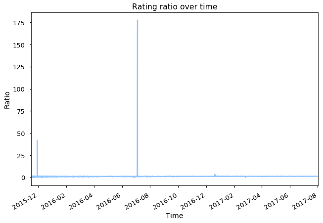

```python
df['ratio'].plot()
plt.style.use('seaborn-talk')
plt.xlabel('Time')
plt.ylabel('Ratio')
plt.title('Rating ratio over time')
plt.savefig('ratio.png')
plt.show()
#there are two outliers .
```

```python
# removing outliers for a better view
df = df[df.ratio < 25]
```

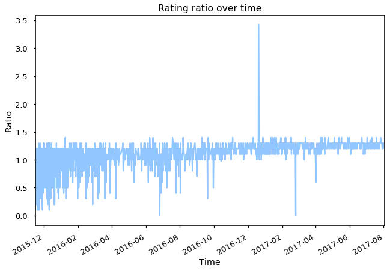

```python
df['ratio'].plot()
plt.xlabel('Time')
plt.ylabel('Ratio')
plt.title('Rating ratio over time')
plt.savefig('ratio_1.png')
plt.show()
```

```python
#here also there is an outlier which is acuatually an wrong rating_numerator
df[df.ratio > 3]
```

| timestamp | retweet_count | favorite_count | rating_numerator | rating_denominator | expanded_urls | ratio |
| --- | --- | --- | --- | --- | --- | --- |
| 2016-12-19 23:06:23 | 1617 | 5845 | 24.0 | 7.0 | https://www.gofundme.com/sams-smile,https://twitter.com/dog_rates/status/810984652412424192/photo/1 | 3.428571 |

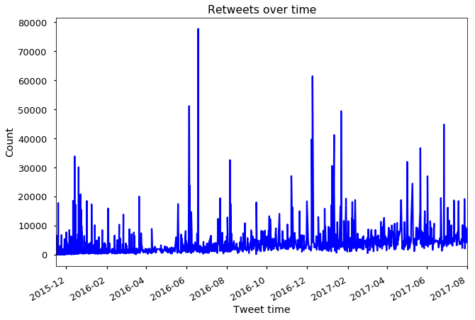

```python
df['retweet_count'].plot(color = 'blue', label='Retweets')
plt.xlabel('Tweet time')
plt.ylabel('Count')
plt.title('Retweets over time')
plt.savefig('retweet.png')
plt.show()
```

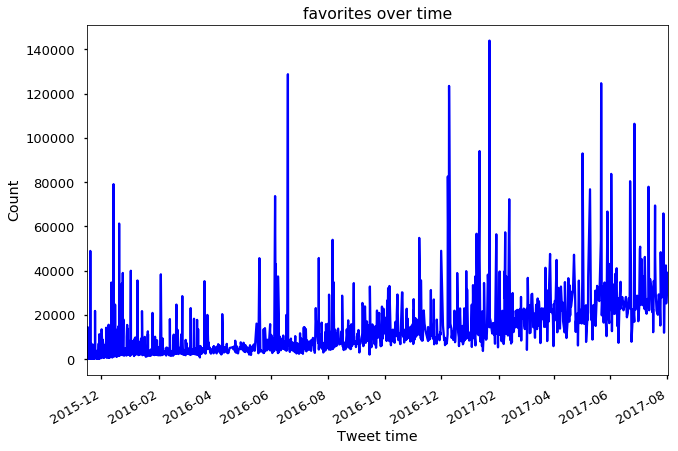

```python
df['favorite_count'].plot(color = 'blue', label='favorite')
plt.xlabel('Tweet time')
plt.ylabel('Count')
plt.title('favorites over time')
plt.savefig('favorites.png')
plt.show()
```